# MODELO PREDICTIVO DE CLASIFICACIÓN: CANCELACION DE RESERVAS DE HOTEL

Carito Ramos

2024-09-30

## 1. INTRODUCCION

En la era digital, los canales de reserva hotelera en línea han transformado drásticamente las posibilidades de reserva y el comportamiento de los clientes. Sin embargo, este cambio ha traído consigo un reto importante para los hoteles: un número significativo de reservas se cancela o no se cumple, conocido como “no-show”. Las cancelaciones suelen deberse a cambios de planes, conflictos de programación, entre otros factores. Estas cancelaciones se ven facilitadas por la opción de hacerlo sin costo o a un precio bajo, lo cual beneficia a los clientes, pero puede ser perjudicial para los hoteles, afectando sus ingresos.

La data utilizada para el presente trabajo se obtuvo del siguiente sitio Kaggle: https://www.kaggle.com/code/ilyai332/eda-visualization-correlations-prediction/input

y contiene información detallada de las reservas de clientes, incluyendo el número de adultos y niños, duración de la estancia, tipo de habitación, solicitudes especiales y más. Con esta información, el objetivo es predecir si un cliente honrará su reserva o la cancelará, permitiendo a los hoteles gestionar mejor su capacidad y reducir el impacto financiero de las cancelaciones.

### 1.1. DICCIONARIO DE DATOS:

[output not shown]

### 1.2. OBJETIVO

El objetivo de este análisis es desarrollar un modelo predictivo capaz de anticipar si un cliente honrará su reserva o la cancelará, utilizando datos históricos de reservas hoteleras. Esto permitirá a los hoteles mejorar su gestión de capacidad, reducir las pérdidas por cancelaciones y optimizar sus ingresos, ajustando sus estrategias de reserva en función de los comportamientos de los clientes.

## 2. LIBRERIAS

```r
library(dplyr)
library(tidyverse)
```

```r
library(ggplot2)
library(conflicted)
conflicts_prefer(dplyr::filter)
```

```
## [conflicted] Will prefer dplyr::filter over any other package.
```

```r
conflicts_prefer(dplyr::recode)
```

```
## [conflicted] Will prefer dplyr::recode over any other package.
```

```r
conflicts_prefer(dplyr::rename)
```

```
## [conflicted] Will prefer dplyr::rename over any other package.
```

```r
conflicts_prefer(gtsummary::select)
```

```
## [conflicted] Will prefer gtsummary::select over any other package.
```

```r
library(VIM)#Visualizacion de valores perdidos
library(DMwR)# Imputacion de datos
library(missMDA)# Imputacion de datos
library(arules)#Discretizacion
library(reshape)# Estandarización
library(mvoutlier)# Visualizacion de outlier multivariados
library(caret)# Trasnformacion con el método boxo-cox
library(randomForest)
```

```r
library(ggcorrplot)
library(skimr)
library(gridExtra)
library(rpart)# Árboles..
library(partykit)# Visualizacion
library(neuralnet)
library(gtsummary)
library(mlbench)
library(caTools)
library(MASS)
library(themis)
library(OptimalCutpoints)
library(tidymodels)
library(class)
library(e1071)         # Para SVM
library(gbm)
library(recipes) # Para transformar a dummy y escalar var numericas
library(pROC)
```

## 3. LECTURA DE DATOS

```r
df <- read.csv("https://raw.githubusercontent.com/CaritoRamos/DataSets/refs/heads/main/Hotel%20Reservations.csv", sep=",")
head(df)
```

```
##   Booking_ID no_of_adults no_of_children no_of_weekend_nights no_of_week_nights
## 1   INN00001            2              0                    1                 2
## 2   INN00002            2              0                    2                 3
## 3   INN00003            1              0                    2                 1
## 4   INN00004            2              0                    0                 2
## 5   INN00005            2              0                    1                 1
## 6   INN00006            2              0                    0                 2
##   type_of_meal_plan required_car_parking_space room_type_reserved lead_time
## 1       Meal Plan 1                          0        Room_Type 1       224
## 2      Not Selected                          0        Room_Type 1         5
## 3       Meal Plan 1                          0        Room_Type 1         1
## 4       Meal Plan 1                          0        Room_Type 1       211
## 5      Not Selected                          0        Room_Type 1        48
## 6       Meal Plan 2                          0        Room_Type 1       346
##   arrival_year arrival_month arrival_date market_segment_type repeated_guest
```

[output cut: 20 more lines]

```r
summary(df) #resumen estadístico de las variables en el dataframe
```

```
##   Booking_ID         no_of_adults   no_of_children    no_of_weekend_nights
##  Length:36275       Min.   :0.000   Min.   : 0.0000   Min.   :0.0000
##  Class :character   1st Qu.:2.000   1st Qu.: 0.0000   1st Qu.:0.0000
##  Mode  :character   Median :2.000   Median : 0.0000   Median :1.0000
##                     Mean   :1.845   Mean   : 0.1053   Mean   :0.8107
##                     3rd Qu.:2.000   3rd Qu.: 0.0000   3rd Qu.:2.0000
##                     Max.   :4.000   Max.   :10.0000   Max.   :7.0000
##  no_of_week_nights type_of_meal_plan  required_car_parking_space
##  Min.   : 0.000    Length:36275       Min.   :0.00000
##  1st Qu.: 1.000    Class :character   1st Qu.:0.00000
##  Median : 2.000    Mode  :character   Median :0.00000
##  Mean   : 2.204                       Mean   :0.03099
##  3rd Qu.: 3.000                       3rd Qu.:0.00000
##  Max.   :17.000                       Max.   :1.00000
##  room_type_reserved   lead_time       arrival_year  arrival_month
##  Length:36275       Min.   :  0.00   Min.   :2017   Min.   : 1.000
##  Class :character   1st Qu.: 17.00   1st Qu.:2018   1st Qu.: 5.000
##  Mode  :character   Median : 57.00   Median :2018   Median : 8.000
##                     Mean   : 85.23   Mean   :2018   Mean   : 7.424
##                     3rd Qu.:126.00   3rd Qu.:2018   3rd Qu.:10.000
##                     Max.   :443.00   Max.   :2018   Max.   :12.000
##   arrival_date  market_segment_type repeated_guest
##  Min.   : 1.0   Length:36275        Min.   :0.00000
##  1st Qu.: 8.0   Class :character    1st Qu.:0.00000
##  Median :16.0   Mode  :character    Median :0.00000
##  Mean   :15.6                       Mean   :0.02564
##  3rd Qu.:23.0                       3rd Qu.:0.00000
##  Max.   :31.0                       Max.   :1.00000
##  no_of_previous_cancellations no_of_previous_bookings_not_canceled
##  Min.   : 0.00000             Min.   : 0.0000
##  1st Qu.: 0.00000             1st Qu.: 0.0000
##  Median : 0.00000             Median : 0.0000
##  Mean   : 0.02335             Mean   : 0.1534
##  3rd Qu.: 0.00000             3rd Qu.: 0.0000
##  Max.   :13.00000             Max.   :58.0000
##  avg_price_per_room no_of_special_requests booking_status
##  Min.   :  0.00     Min.   :0.0000         Length:36275
##  1st Qu.: 80.30     1st Qu.:0.0000         Class :character
##  Median : 99.45     Median :0.0000         Mode  :character
##  Mean   :103.42     Mean   :0.6197
##  3rd Qu.:120.00     3rd Qu.:1.0000
##  Max.   :540.00     Max.   :5.0000
```

```r
str(df)
```

```
## 'data.frame':    36275 obs. of  19 variables:
##  $ Booking_ID                          : chr  "INN00001" "INN00002" "INN00003" "INN00004" ...
##  $ no_of_adults                        : int  2 2 1 2 2 2 2 2 3 2 ...
##  $ no_of_children                      : int  0 0 0 0 0 0 0 0 0 0 ...
##  $ no_of_weekend_nights                : int  1 2 2 0 1 0 1 1 0 0 ...
##  $ no_of_week_nights                   : int  2 3 1 2 1 2 3 3 4 5 ...
##  $ type_of_meal_plan                   : chr  "Meal Plan 1" "Not Selected" "Meal Plan 1" "Meal Plan 1" ...
##  $ required_car_parking_space          : int  0 0 0 0 0 0 0 0 0 0 ...
##  $ room_type_reserved                  : chr  "Room_Type 1" "Room_Type 1" "Room_Type 1" "Room_Type 1" ...
##  $ lead_time                           : int  224 5 1 211 48 346 34 83 121 44 ...
##  $ arrival_year                        : int  2017 2018 2018 2018 2018 2018 2017 2018 2018 2018 ...
##  $ arrival_month                       : int  10 11 2 5 4 9 10 12 7 10 ...
##  $ arrival_date                        : int  2 6 28 20 11 13 15 26 6 18 ...
##  $ market_segment_type                 : chr  "Offline" "Online" "Online" "Online" ...
##  $ repeated_guest                      : int  0 0 0 0 0 0 0 0 0 0 ...
##  $ no_of_previous_cancellations        : int  0 0 0 0 0 0 0 0 0 0 ...
##  $ no_of_previous_bookings_not_canceled: int  0 0 0 0 0 0 0 0 0 0 ...
##  $ avg_price_per_room                  : num  65 106.7 60 100 94.5 ...
##  $ no_of_special_requests              : int  0 1 0 0 0 1 1 1 1 3 ...
##  $ booking_status                      : chr  "Not_Canceled" "Not_Canceled" "Canceled" "Canceled" ...
```

## 4. DATA WRANGLING

### 4.1. EXPLORACION DE LOS DATOS

```r
#Nombres de las columnas del df
colnames(df)
```

```
##  [1] "Booking_ID"
##  [2] "no_of_adults"
##  [3] "no_of_children"
##  [4] "no_of_weekend_nights"
##  [5] "no_of_week_nights"
##  [6] "type_of_meal_plan"
##  [7] "required_car_parking_space"
##  [8] "room_type_reserved"
##  [9] "lead_time"
## [10] "arrival_year"
## [11] "arrival_month"
## [12] "arrival_date"
## [13] "market_segment_type"
## [14] "repeated_guest"
## [15] "no_of_previous_cancellations"
## [16] "no_of_previous_bookings_not_canceled"
## [17] "avg_price_per_room"
## [18] "no_of_special_requests"
## [19] "booking_status"
```

```r
#Exploramos recuento de valores de cada columna
for (i in colnames(df)[-1]) {  # Omitimos la primera columna
  print(paste("Table:", i))
  print(table(df[[i]]))
}
```

```
## [1] "Table: no_of_adults"
##
##     0     1     2     3     4
##   139  7695 26108  2317    16
## [1] "Table: no_of_children"
##
##     0     1     2     3     9    10
## 33577  1618  1058    19     2     1
## [1] "Table: no_of_weekend_nights"
##
##     0     1     2     3     4     5     6     7
## 16872  9995  9071   153   129    34    20     1
## [1] "Table: no_of_week_nights"
##
##     0     1     2     3     4     5     6     7     8     9    10    11    12
##  2387  9488 11444  7839  2990  1614   189   113    62    34    62    17     9
##    13    14    15    16    17
##     5     7    10     2     3
## [1] "Table: type_of_meal_plan"
##
##  Meal Plan 1  Meal Plan 2  Meal Plan 3 Not Selected
##        27835         3305            5         5130
## [1] "Table: required_car_parking_space"
##
##     0     1
## 35151  1124
## [1] "Table: room_type_reserved"
##
## Room_Type 1 Room_Type 2 Room_Type 3 Room_Type 4 Room_Type 5 Room_Type 6
##       28130         692           7        6057         265         966
## Room_Type 7
##         158
## [1] "Table: lead_time"
##
##    0    1    2    3    4    5    6    7    8    9   10   11   12   13   14   15
## 1297 1078  643  630  628  577  519  429  436  332  317  371  412  332  384  298
##   16   17   18   19   20   21   22   23   24   25   26   27   28   29   30   31
##  255  288  302  316  244  237  250  216  222  197  214  221  262  245  259  247
##   32   33   34   35   36   37   38   39   40   41   42   43   44   45   46   47
##  283  230  242  264  259  337  175  335  231  218  170  163  238  183  161  197
```

[output cut: 787 more lines]

```
##      1      1      1      1      1      1      1      1      1      2      1
##  269.3  274.2    275    277    278  278.9  279.2 283.67  284.1 285.17    288
##      2      1      1      1      2      1      1      1      1      2      1
##    289    294    296    297 299.33    300    306  314.1    316 332.57 349.63
##      1      1      1      1      1      5      2      1      1      1      1
##    365  375.5    540
##      1      1      1
## [1] "Table: no_of_special_requests"
##
##     0     1     2     3     4     5
## 19777 11373  4364   675    78     8
## [1] "Table: booking_status"
##
##     Canceled Not_Canceled
##        11885        24390
```

```r
#Renombramos las columnas:
df <- df %>% rename(,adults = "no_of_adults",
          children = "no_of_children",
          weekend_nights = "no_of_weekend_nights",
          weekday_nights ="no_of_week_nights",
          meal_plan ="type_of_meal_plan",
          car_parking_required = "required_car_parking_space",
          room_type = "room_type_reserved",
          high_season = "arrival_month",
          market_segment = "market_segment_type",
          previous_cancellations = "no_of_previous_cancellations",
          bookings_not_canceled = "no_of_previous_bookings_not_canceled",
          avg_price_room = "avg_price_per_room",
          special_requests = "no_of_special_requests",
          target ="booking_status")
```

```r
#Renombramos los valores de "room_type"
df <- df %>%
  mutate(room_type = recode(room_type,
                                     "Room_Type 1" = "Type 1",
                                     "Room_Type 2" = "Type 2",
                                     "Room_Type 3" = "Type 3",
                                     "Room_Type 4" = "Type 4",
                                     "Room_Type 5" = "Type 5",
                                     "Room_Type 6" = "Type 6",
                                     "Room_Type 7" = "Type 7"))
```

De los resultados obtenidos previamente, se tiene que:

- La variable “repeated_guest” posee dos únicos valores por lo que, a pesar de ser numéricas se considerará como categórica, junto con las variables: “meal_plan”, “room_type”, “arrival_month”, “segment”, incluido el target.
- Por otro lado se observa que para un mejor análisis las variables: “children”, “previous_cancellations”, “special_requests”deben binarizarse.
- También se identifica la posibilidad de simplificar la variable “arrival_month” agrupando los datos en dos categorías: temporada alta y temporada baja.
- Finalmente, se observa que la variable “total_nights” debe binarizarse en función de estadías cortas o largas para un mejor análisis.

### 4.2. TRATAMIENTO DE LOS DATOS

#### DATOS FALTANTES

```r
#Verificamos datos faltantes:
any(is.na(df))  # Verifica si hay algún dato faltante en todo el df
```

```
## [1] FALSE
```

```r
sum(is.na(df))  # Cuenta cuántos datos faltan en total
```

```
## [1] 0
```

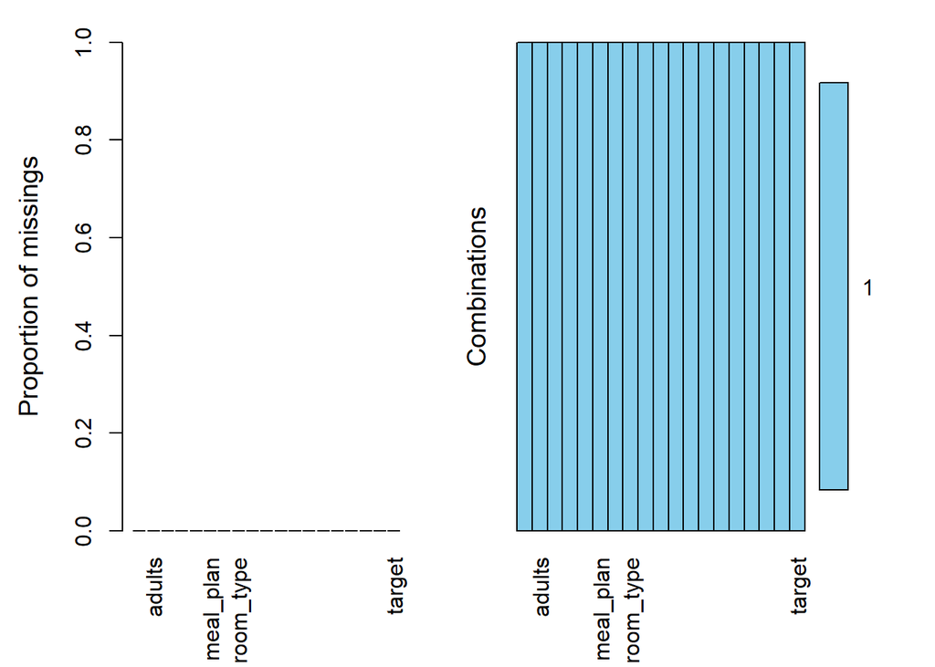

```r
#Para obtener una matriz que te indique en qué filas y columnas faltan datos:
VIM::aggr(df, numbers = T)
```

#### VALORES INFINITOS

```r
inf_values <- sapply(df, function(x) sum(is.infinite(x)))
inf_values
```

```
##             Booking_ID                 adults               children
##                      0                      0                      0
##         weekend_nights         weekday_nights              meal_plan
##                      0                      0                      0
##   car_parking_required              room_type              lead_time
##                      0                      0                      0
##           arrival_year            high_season           arrival_date
##                      0                      0                      0
##         market_segment         repeated_guest previous_cancellations
##                      0                      0                      0
##  bookings_not_canceled         avg_price_room       special_requests
##                      0                      0                      0
##                 target
##                      0
```

#### DUPLICADOS

```r
#Identificando duplicados
num_duplicados <- sum(duplicated(df))
num_duplicados
```

```
## [1] 0
```

```r
#Filas duplicadas
duplicados <- df[duplicated(df), ]
duplicados
```

```
##  [1] Booking_ID             adults                 children
##  [4] weekend_nights         weekday_nights         meal_plan
##  [7] car_parking_required   room_type              lead_time
## [10] arrival_year           high_season            arrival_date
## [13] market_segment         repeated_guest         previous_cancellations
## [16] bookings_not_canceled  avg_price_room         special_requests
## [19] target
## <0 rows> (o 0- extensión row.names)
```

### 4.3. TRANSFORMACION DE VARIABLES

#### CREACION DE COLUMNAS

```r
#Creando columna "Total_guests"
df <- df %>%
  mutate(total_guests = adults + children)

df %>%
  select(adults, children, total_guests) %>%
  head()
```

```
##   adults children total_guests
## 1      2        0            2
## 2      2        0            2
## 3      1        0            1
## 4      2        0            2
## 5      2        0            2
## 6      2        0            2
```

```r
table(df$total_guests)
```

```
##
##     1     2     3     4     5    10    11    12
##  7552 23942  3851   912    15     1     1     1
```

Para simplificar el análisis y facilitar la identificación de patrones de comportamiento específicos, se propone binarizar la variable “total_guests” en función de si hay un solo huésped o más de uno.

```r
#Creando la columna "Total_nights"
df <- df %>%
  mutate(total_nights = weekend_nights + weekday_nights)

df %>%
  select(weekend_nights, weekday_nights, total_nights) %>%
  head()
```

```
##   weekend_nights weekday_nights total_nights
## 1              1              2            3
## 2              2              3            5
## 3              2              1            3
## 4              0              2            2
## 5              1              1            2
## 6              0              2            2
```

```r
table(df$total_nights)
```

```
##
##     0     1     2     3     4     5     6     7     8     9    10    11    12
##    78  6604  8472 10052  5893  2589  1031   973   179   111   109    39    24
##    13    14    15    16    17    18    19    20    21    22    23    24
##    18    32    31     6     5     3     6    11     4     2     2     1
```

Se propone binarizar la variable “total_nights” de manera similar a “total_guests”, clasificando las reservas en “estancia corta” (tres noches o menos) y “estancia larga” (más de tres noches), basándose en la distribución de la variable. Esta binarización simplifica el análisis al enfocarse en dos categorías clave, facilitando la comprensión del comportamiento de los clientes en relación con la duración de su estancia.

```r
#Creando la columna "total_stay_price"
df <- df %>%
  mutate(total_stay_price = avg_price_room * total_nights)

df %>%
  select(avg_price_room, total_nights, total_stay_price) %>%
  head()
```

```
##   avg_price_room total_nights total_stay_price
## 1          65.00            3            195.0
## 2         106.68            5            533.4
## 3          60.00            3            180.0
## 4         100.00            2            200.0
## 5          94.50            2            189.0
## 6         115.00            2            230.0
```

#### ELIMINACION DE COLUMNAS

- Como primer paso, evaluaremos la relevancia de las variables verificando su sesgo y varianza. Las variables con baja varianza tienden a tener un menor poder explicativo o predictivo, ya que no logran distinguir adecuadamente entre los casos. Si los valores son muy similares entre sí, la variable aporta poco valor para separar o clasificar las observaciones. Además, en muchos análisis predictivos, las variables con baja varianza suelen eliminarse porque no añaden valor al modelo y, en algunos casos, pueden introducir ruido.

```r
#Identificando variables con baja varianza:
low_variance_vars <- nearZeroVar(df, saveMetrics = TRUE)
low_variance_cols <- rownames(low_variance_vars[low_variance_vars$nzv == TRUE, ])
low_variance_cols
```

```
## [1] "children"               "car_parking_required"   "repeated_guest"
## [4] "previous_cancellations" "bookings_not_canceled"
```

- Luego de los resultados, consideramos que las variables “children”, “previous_cancellations” y “repeated_guest” pueden influir significativamente sobre el target por lo que sería conveniente no eliminarlas aún.
- Finalmente eliminaremos las siguientes variables por considerarse irrelevantes para el presente análisis: “avg_price_room”, “adults”, “weekend_nights”, “weekday_nights”, “arrival_year”, “car_parking_required” y “bookings_not_canceled”.

```r
#Eliminando columnas irrelevantes
df <- df %>% select(-Booking_ID, -weekend_nights,-weekday_nights,-adults, -arrival_year, -arrival_date, -bookings_not_canceled, -avg_price_room, -car_parking_required)
```

```r
head(df)
```

```
##   children    meal_plan room_type lead_time high_season market_segment
## 1        0  Meal Plan 1    Type 1       224          10        Offline
## 2        0 Not Selected    Type 1         5          11         Online
## 3        0  Meal Plan 1    Type 1         1           2         Online
## 4        0  Meal Plan 1    Type 1       211           5         Online
## 5        0 Not Selected    Type 1        48           4         Online
## 6        0  Meal Plan 2    Type 1       346           9         Online
##   repeated_guest previous_cancellations special_requests       target
## 1              0                      0                0 Not_Canceled
## 2              0                      0                1 Not_Canceled
## 3              0                      0                0     Canceled
## 4              0                      0                0     Canceled
## 5              0                      0                0     Canceled
## 6              0                      0                1     Canceled
##   total_guests total_nights total_stay_price
## 1            2            3            195.0
## 2            2            5            533.4
## 3            1            3            180.0
## 4            2            2            200.0
## 5            2            2            189.0
## 6            2            2            230.0
```

#### BINARIZACION DE VARIABLES

```r
#Binarización del "target"
df <- df %>%
  mutate(target = recode(target,"Canceled" = 1,"Not_Canceled" = 0))
```

```r
#Binarización de la variable "children"
df$children <- ifelse(df$children == 0, 0, 1)
head(df$children)
```

```
## [1] 0 0 0 0 0 0
```

```r
tail(df$children)
```

```
## [1] 1 0 0 0 0 0
```

```r
#Binarización de la variable  "previous_cancellations"
df$previous_cancellations <- ifelse(df$previous_cancellations == 0, 0, 1)
head(df$previous_cancellations)
```

```
## [1] 0 0 0 0 0 0
```

```r
tail(df$previous_cancellations)
```

```
## [1] 0 0 0 0 0 0
```

```r
#Binarización de la variable  "special_requests"
df$special_requests <- ifelse(df$special_requests == 0, 0, 1)
head(df$special_requests)
```

```
## [1] 0 1 0 0 0 1
```

```r
tail(df$special_requests)
```

```
## [1] 0 1 1 1 0 0
```

```r
#Cambio de valores de la variable  "repeated_guest"
df$repeated_guest <- ifelse(df$repeated_guest == 0, 0, 1)
head(df$repeated_guest)
```

```
## [1] 0 0 0 0 0 0
```

```r
tail(df$repeated_guest)
```

```
## [1] 0 0 0 0 0 0
```

```r
# Binarización de la variable "total_guests" y cambio de nombre
df <- df %>% rename(,single_guest = "total_guests")

df$single_guest <- ifelse(df$single_guest == 1, 1, 0)
head(df$single_guest)
```

```
## [1] 0 0 1 0 0 0
```

```r
tail(df$single_guest)
```

```
## [1] 0 0 0 0 0 0
```

```r
# Binarización de la variable "total_nights" y cambio de nombre
df <- df %>% rename(,short_stay = "total_nights")

df$short_stay <- ifelse(df$short_stay <= 3, 1, 0)
head(df$short_stay)
```

```
## [1] 1 0 1 1 1 1
```

```r
tail(df$short_stay)
```

```
## [1] 1 0 0 0 1 1
```

```r
#Binarización de la variable  "arrival_month"

#Primero queremos saber qué meses son temporada alta considerando que si se iguala o supera la media entonces es temporada alta
frequencies <- c(2736, 3813, 3021, 1704, 1014, 2920, 3203, 2358, 2598, 2980, 5317, 4611)
months <- c(4,8,12,2,1,7,6,3,5,11,10,9)

mean_frequency <- mean(frequencies)
df_freq <- data.frame(month = months, frequency = frequencies)
high_demand_months <- df_freq[df_freq$frequency >= mean_frequency, ] #Identificar los meses con alta demanda

# Mostrar resultados
mean_frequency
```

```
## [1] 3022.917
```

```r
high_demand_months
```

```
##    month frequency
## 2      8      3813
## 7      6      3203
## 11    10      5317
## 12     9      4611
```

```r
df$high_season = ifelse(df$high_season %in% c(6, 8, 9, 10), 1, 0)

head(df$high_season)
```

```
## [1] 1 0 0 0 0 1
```

```r
tail(df$high_season)
```

```
## [1] 1 1 1 0 0 0
```

```r
head(df)
```

```
##   children    meal_plan room_type lead_time high_season market_segment
## 1        0  Meal Plan 1    Type 1       224           1        Offline
## 2        0 Not Selected    Type 1         5           0         Online
## 3        0  Meal Plan 1    Type 1         1           0         Online
## 4        0  Meal Plan 1    Type 1       211           0         Online
## 5        0 Not Selected    Type 1        48           0         Online
## 6        0  Meal Plan 2    Type 1       346           1         Online
##   repeated_guest previous_cancellations special_requests target single_guest
## 1              0                      0                0      0            0
## 2              0                      0                1      0            0
## 3              0                      0                0      1            1
## 4              0                      0                0      1            0
## 5              0                      0                0      1            0
## 6              0                      0                1      1            0
##   short_stay total_stay_price
## 1          1            195.0
## 2          0            533.4
## 3          1            180.0
## 4          1            200.0
## 5          1            189.0
## 6          1            230.0
```

#### VARIABLES CATEGORICAS

```r
colnames(df)
```

```
##  [1] "children"               "meal_plan"              "room_type"
##  [4] "lead_time"              "high_season"            "market_segment"
##  [7] "repeated_guest"         "previous_cancellations" "special_requests"
## [10] "target"                 "single_guest"           "short_stay"
## [13] "total_stay_price"
```

```r
#Variables categóricas
cat_vars <- df %>%
  select_if(~is.character(.)) %>%
  colnames()

cat_vars
```

```
## [1] "meal_plan"      "room_type"      "market_segment"
```

#### TRANSFORMACION DE VARIABLES CATEGORICAS A FACTOR

```r
#Transformamos las variables categóricas a factor.
for (i in cat_vars){
  df[,i] <- factor(df[,i])
}
str(df)
```

```
## 'data.frame':    36275 obs. of  13 variables:
##  $ children              : num  0 0 0 0 0 0 0 0 0 0 ...
##  $ meal_plan             : Factor w/ 4 levels "Meal Plan 1",..: 1 4 1 1 4 2 1 1 1 1 ...
##  $ room_type             : Factor w/ 7 levels "Type 1","Type 2",..: 1 1 1 1 1 1 1 4 1 4 ...
##  $ lead_time             : int  224 5 1 211 48 346 34 83 121 44 ...
##  $ high_season           : num  1 0 0 0 0 1 1 0 0 1 ...
##  $ market_segment        : Factor w/ 5 levels "Aviation","Complementary",..: 4 5 5 5 5 5 5 5 4 5 ...
##  $ repeated_guest        : num  0 0 0 0 0 0 0 0 0 0 ...
##  $ previous_cancellations: num  0 0 0 0 0 0 0 0 0 0 ...
##  $ special_requests      : num  0 1 0 0 0 1 1 1 1 1 ...
##  $ target                : num  0 0 1 1 1 1 0 0 0 0 ...
##  $ single_guest          : num  0 0 1 0 0 0 0 0 0 0 ...
##  $ short_stay            : num  1 0 1 1 1 1 0 0 0 0 ...
##  $ total_stay_price      : num  195 533 180 200 189 ...
```

Las variables “target”; “children”, “repeated_guest”, “previous_cancellations”, “high_season”, “single_guest”, “short_stay” y “special_requests” son binomiales por lo que serán convertidas a factor.

```r
df$target <- as.factor(df$target)
df$children <- as.factor(df$children)
df$repeated_guest <- as.factor(df$repeated_guest)
df$previous_cancellations <- as.factor(df$previous_cancellations)
df$high_season <- as.factor(df$high_season)
df$special_requests <- as.factor(df$special_requests)
df$single_guest <- as.factor(df$single_guest)
df$short_stay  <- as.factor(df$short_stay )

str(df)
```

```
## 'data.frame':    36275 obs. of  13 variables:
##  $ children              : Factor w/ 2 levels "0","1": 1 1 1 1 1 1 1 1 1 1 ...
##  $ meal_plan             : Factor w/ 4 levels "Meal Plan 1",..: 1 4 1 1 4 2 1 1 1 1 ...
##  $ room_type             : Factor w/ 7 levels "Type 1","Type 2",..: 1 1 1 1 1 1 1 4 1 4 ...
##  $ lead_time             : int  224 5 1 211 48 346 34 83 121 44 ...
##  $ high_season           : Factor w/ 2 levels "0","1": 2 1 1 1 1 2 2 1 1 2 ...
##  $ market_segment        : Factor w/ 5 levels "Aviation","Complementary",..: 4 5 5 5 5 5 5 5 4 5 ...
##  $ repeated_guest        : Factor w/ 2 levels "0","1": 1 1 1 1 1 1 1 1 1 1 ...
##  $ previous_cancellations: Factor w/ 2 levels "0","1": 1 1 1 1 1 1 1 1 1 1 ...
##  $ special_requests      : Factor w/ 2 levels "0","1": 1 2 1 1 1 2 2 2 2 2 ...
##  $ target                : Factor w/ 2 levels "0","1": 1 1 2 2 2 2 1 1 1 1 ...
##  $ single_guest          : Factor w/ 2 levels "0","1": 1 1 2 1 1 1 1 1 1 1 ...
##  $ short_stay            : Factor w/ 2 levels "0","1": 2 1 2 2 2 2 1 1 1 1 ...
##  $ total_stay_price      : num  195 533 180 200 189 ...
```

```r
#Actualizamos las variables categóricas:
#Variables categóricas
cat_vars <- df %>%
  select_if(~is.factor(.)) %>%
  colnames()

cat_vars
```

```
##  [1] "children"               "meal_plan"              "room_type"
##  [4] "high_season"            "market_segment"         "repeated_guest"
##  [7] "previous_cancellations" "special_requests"       "target"
## [10] "single_guest"           "short_stay"
```

```r
#Para conocer los levels que tiene cada variable categórica:
for (i in cat_vars){
  cat(i, ":", levels(df[[i]]), "\n")
}
```

```
## children : 0 1
## meal_plan : Meal Plan 1 Meal Plan 2 Meal Plan 3 Not Selected
## room_type : Type 1 Type 2 Type 3 Type 4 Type 5 Type 6 Type 7
## high_season : 0 1
## market_segment : Aviation Complementary Corporate Offline Online
## repeated_guest : 0 1
## previous_cancellations : 0 1
## special_requests : 0 1
## target : 0 1
## single_guest : 0 1
## short_stay : 0 1
```

#### VARIABLES NUMERICAS

```r
#Variables numéricas
num_vars <- df %>%
  select_if(is.numeric) %>%
  colnames()

num_vars
```

```
## [1] "lead_time"        "total_stay_price"
```

### 4.4. TRATAMIENTO DE OUTLIERS

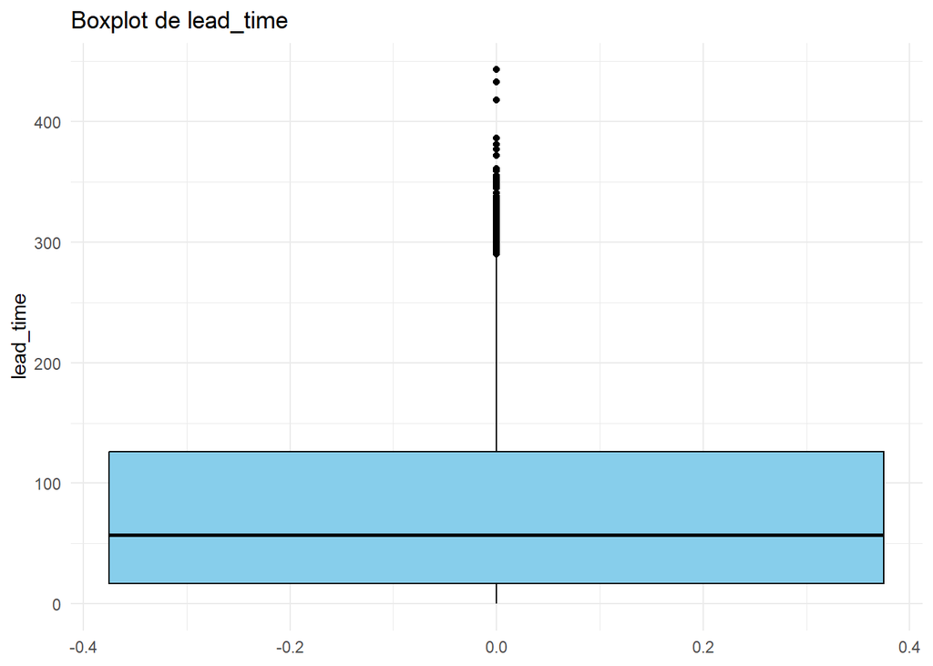

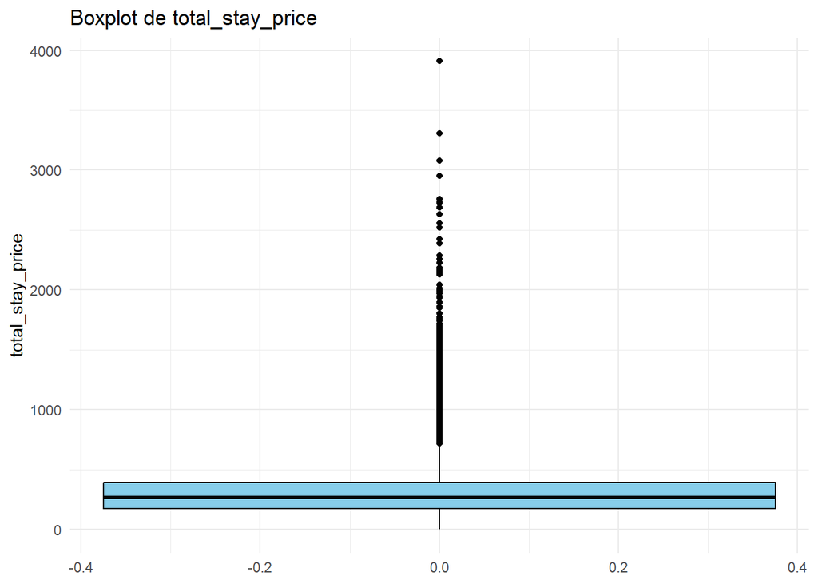

```r
#Visualización de la distribución de las variables numéricas
for (i in num_vars) {

  box_plot <- df %>%
    ggplot(aes(y = !!sym(i))) +
    geom_boxplot(fill = "skyblue", color = "black") +
    ggtitle(paste("Boxplot de", i)) +
    theme_minimal()

  grid.arrange(box_plot, ncol = 1)

}
```

```r
outliers <- c("total_stay_price", "lead_time")
```

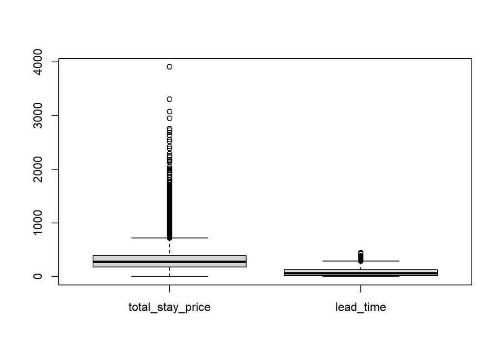

```r
df_outliers <- df[ , outliers]
boxplot(df_outliers)
```

```r
#Funcion para indicar la posicion de los valores atipicos
OutlierR <- function(x){
  out <- boxplot.stats(x)$out
  pos<-which(x%in%out)
  names(out)<-pos
  return(out)
}
apply(df_outliers,2,OutlierR)
```

```
## $total_stay_price
##      79      95     115     117     118     140     163     195     228     236
##  850.85  781.13  736.96  950.32  719.81  856.32  862.40 1664.32  803.00  761.04
##     241     260     280     287     300     314     342     353     369     371
##  723.60  945.00  949.48  751.40  740.32  721.63  725.90 1160.00  850.50  995.00
##     374     381     396     429     449     464     493     540     555     558
##  740.00 1749.30  760.50  832.00 1014.00  800.96  768.67 2689.26 2420.86  740.00
##     563     585     594     596     680     682     718     733     738     750
##  910.35  838.95  871.22  850.50  740.00  862.75  837.90 2225.30  767.55  747.00
##     773     817     899     934    1020    1074    1078    1163    1184    1277
## 1436.52 1138.50  794.97  842.50 1075.00  722.00  852.00 1144.98  759.90 1484.42
##    1325    1451    1455    1456    1487    1492    1509    1547    1589    1604
##  810.90  828.00 1122.00  751.40 1180.02  985.98 1268.12  728.00 1805.00  720.00
##    1606    1668    1788    1790    1791    1800    1824    1853    1857    1880
##  731.00  902.70 1055.64  969.60  791.34  720.00  728.10  766.02  720.00  972.00
##    1886    1892    1967    1976    1979    2007    2026    2042    2051    2083
##  817.00 1317.50  775.00  928.06  793.80  835.20  823.15 1203.72  880.00 1077.00
##    2152    2191    2198    2202    2214    2238    2248    2257    2273    2297
##  818.55 1098.00  841.50  972.00  810.00 1163.04  730.80  986.85 1425.00 1944.00
##    2298    2317    2318    2341    2346    2358    2364    2376    2379    2380
##  889.20  774.90  954.00 1494.24 1112.00  774.97  871.20  856.80  747.00  767.62
##    2410    2423    2426    2438    2443    2459    2470    2475    2477    2482
## 1060.00  756.00  963.00  830.00  874.50  873.53 1088.00 1275.82  722.50  939.26
##    2502    2506    2527    2531    2590    2637    2652    2654    2658    2661
## 1009.80  756.00 1012.50  821.00  739.50  815.40  804.32  909.50  840.00  719.10
##    2669    2696    2711    2793    2795    2800    2825    2865    2881    2946
## 1263.60  934.20 1338.74 1519.77 1012.41  778.32 1241.10  794.75  863.10  787.92
##    2947    2959    2980    3002    3005    3053    3115    3136    3140    3189
## 1418.80  720.00  723.60 1296.00  739.98  752.25  886.50  745.00  885.52  838.08
##    3206    3252    3254    3262    3280    3290    3304    3341    3350    3351
## 1092.00 1436.40  802.41  795.60  765.00 1013.80  972.00  909.50  902.02 1053.15
##    3358    3373    3387    3411    3431    3443    3468    3498    3500    3520
##  720.64  742.98  720.90 1010.28  906.08  729.25  994.50 1073.00  800.01  867.00
##    3575    3598    3599    3602    3613    3647    3668    3670    3744    3764
## 1035.00  792.00  785.40  852.00 1286.11  880.00  756.00  827.89  841.50 1185.00
##    3765    3790    3823    3827    3851    3855    3865    3963    3977    3981
##  915.46  748.80  744.00 1053.92 1535.10  792.00  733.50  887.40  747.00 1458.87
##    3987    4005    4010    4034    4047    4095    4119    4126    4135    4144
##  720.00  901.00 1453.48  813.61 1122.00  850.59  795.60  850.50  994.50  886.48
##    4151    4169    4170    4171    4282    4375    4377    4438    4461    4524
```

[output cut: 502 more lines]

```
##   359   322   304   323   320   377   443   377   305   315   305   301   314
## 34074 34113 34115 34118 34120 34180 34188 34211 34236 34239 34298 34308 34373
##   346   308   320   418   305   292   327   292   386   386   317   335   322
## 34378 34389 34398 34418 34434 34527 34542 34573 34577 34604 34650 34725 34758
##   305   303   320   346   317   291   335   317   418   304   317   317   308
## 34912 34997 34998 35003 35031 35042 35051 35073 35080 35082 35090 35140 35155
##   386   305   296   301   338   301   291   320   292   346   418   302   433
## 35190 35242 35257 35289 35325 35370 35428 35429 35447 35462 35469 35489 35517
##   418   433   298   310   305   418   301   386   317   320   301   386   323
## 35531 35556 35568 35574 35585 35595 35624 35627 35631 35650 35657 35658 35660
##   292   299   301   315   350   418   322   308   351   315   443   304   304
## 35669 35715 35766 35802 35858 35877 35892 35920 35966 36007 36024 36105 36106
##   297   290   301   301   296   296   290   292   303   377   296   309   304
## 36140 36172 36179 36192 36249
##   305   315   386   304   292
```

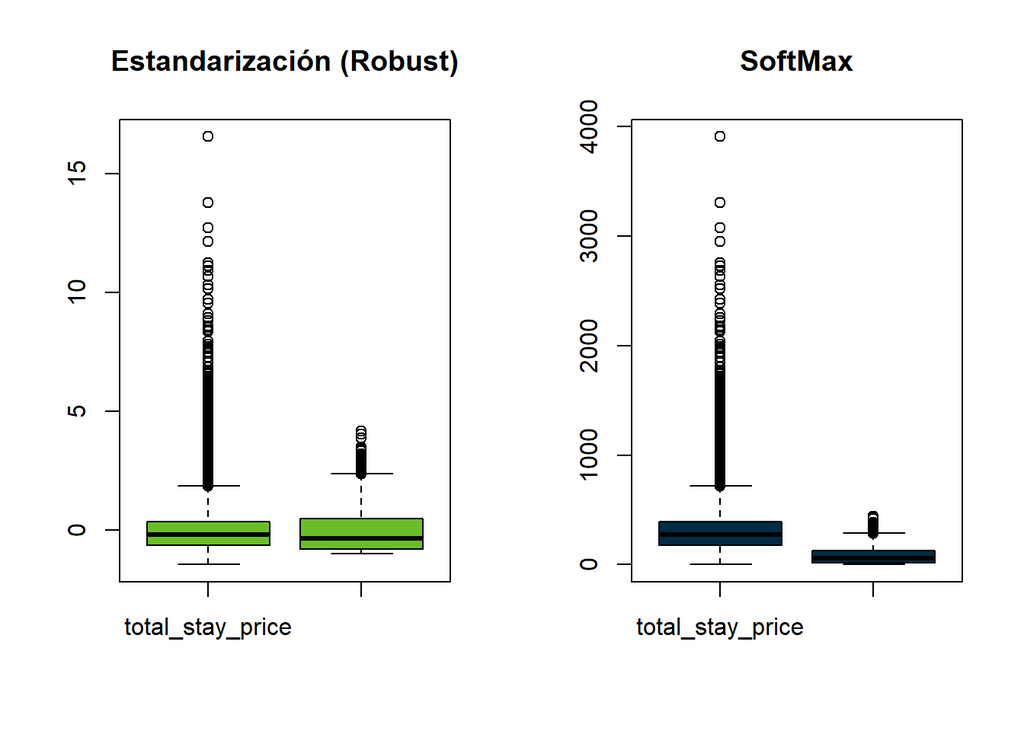

```r
dfTrans <- DMwR::SoftMax(df_outliers,lambda = 2, avg = mean(x, na.rm = T), std = sd(x, na.rm = T))

EstandRob <- reshape ::rescaler(df_outliers)

op <- par(mfrow=c(1,2))
boxplot(EstandRob,
        col = "#69BE28",
        main = "Estandarización (Robust)")

boxplot(df_outliers,
        col="#002C44",
        main="SoftMax")
```

```r
head(dfTrans)
```

```
##      total_stay_price  lead_time
## [1,]        0.1542009 0.99377710
## [2,]        0.9603345 0.05053335
## [3,]        0.1280034 0.04396061
## [4,]        0.1638590 0.99002849
## [5,]        0.1432314 0.20404440
## [6,]        0.2321190 0.99992762
```

```r
df[,c("total_stay_price", "lead_time")] <- dfTrans[, c("total_stay_price", "lead_time")]
head(df)
```

```
##   children    meal_plan room_type  lead_time high_season market_segment
## 1        0  Meal Plan 1    Type 1 0.99377710           1        Offline
## 2        0 Not Selected    Type 1 0.05053335           0         Online
## 3        0  Meal Plan 1    Type 1 0.04396061           0         Online
## 4        0  Meal Plan 1    Type 1 0.99002849           0         Online
## 5        0 Not Selected    Type 1 0.20404440           0         Online
## 6        0  Meal Plan 2    Type 1 0.99992762           1         Online
##   repeated_guest previous_cancellations special_requests target single_guest
## 1              0                      0                0      0            0
## 2              0                      0                1      0            0
## 3              0                      0                0      1            1
## 4              0                      0                0      1            0
## 5              0                      0                0      1            0
## 6              0                      0                1      1            0
##   short_stay total_stay_price
## 1          1        0.1542009
## 2          0        0.9603345
## 3          1        0.1280034
## 4          1        0.1638590
## 5          1        0.1432314
## 6          1        0.2321190
```

```r
str(df)
```

```
## 'data.frame':    36275 obs. of  13 variables:
##  $ children              : Factor w/ 2 levels "0","1": 1 1 1 1 1 1 1 1 1 1 ...
##  $ meal_plan             : Factor w/ 4 levels "Meal Plan 1",..: 1 4 1 1 4 2 1 1 1 1 ...
##  $ room_type             : Factor w/ 7 levels "Type 1","Type 2",..: 1 1 1 1 1 1 1 4 1 4 ...
##  $ lead_time             : num  0.9938 0.0505 0.044 0.99 0.204 ...
##  $ high_season           : Factor w/ 2 levels "0","1": 2 1 1 1 1 2 2 1 1 2 ...
##  $ market_segment        : Factor w/ 5 levels "Aviation","Complementary",..: 4 5 5 5 5 5 5 5 4 5 ...
##  $ repeated_guest        : Factor w/ 2 levels "0","1": 1 1 1 1 1 1 1 1 1 1 ...
##  $ previous_cancellations: Factor w/ 2 levels "0","1": 1 1 1 1 1 1 1 1 1 1 ...
##  $ special_requests      : Factor w/ 2 levels "0","1": 1 2 1 1 1 2 2 2 2 2 ...
##  $ target                : Factor w/ 2 levels "0","1": 1 1 2 2 2 2 1 1 1 1 ...
##  $ single_guest          : Factor w/ 2 levels "0","1": 1 1 2 1 1 1 1 1 1 1 ...
##  $ short_stay            : Factor w/ 2 levels "0","1": 2 1 2 2 2 2 1 1 1 1 ...
##  $ total_stay_price      : num  0.154 0.96 0.128 0.164 0.143 ...
```

## 5. EDA

### 5.1. ANALISIS UNIVARIADO

#### 5.1.1. VARIABLES NUMÉRICAS

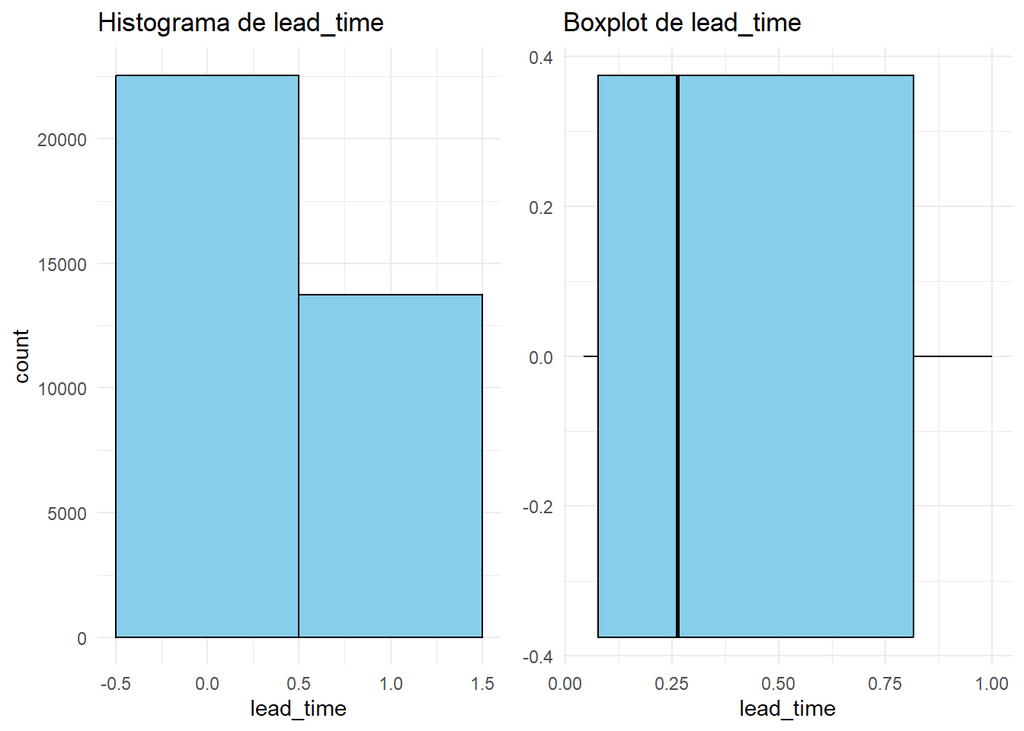

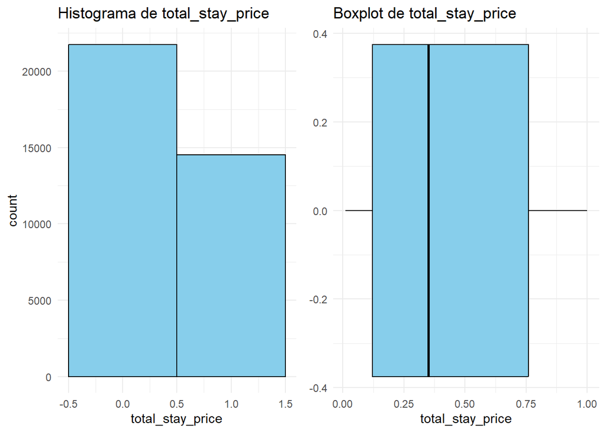

```r
# Visualización de histogramas para las variables numéricas
for (i in num_vars) {

  hist_plot <- df %>%
    ggplot(aes(x = !!sym(i))) +
    geom_histogram(binwidth = 1, fill = "skyblue", color = "black") +
    ggtitle(paste("Histograma de", i)) +
    theme_minimal()

  box_plot <- df %>%
    ggplot(aes(x = !!sym(i))) +
    geom_boxplot(fill = "skyblue", color = "black") +
    ggtitle(paste("Boxplot de", i)) +
    theme_minimal()

  grid.arrange(hist_plot, box_plot, ncol = 2)

}
```

#### 5.1.2. VARIABLES CATEGÓRICAS

```r
# Tabla de frecuencia para cada variable categórica
for (i in cat_vars) {
  print(i)
  print(table(df[[i]]))
}
```

```
## [1] "children"
##
##     0     1
## 33577  2698
## [1] "meal_plan"
##
##  Meal Plan 1  Meal Plan 2  Meal Plan 3 Not Selected
##        27835         3305            5         5130
## [1] "room_type"
##
## Type 1 Type 2 Type 3 Type 4 Type 5 Type 6 Type 7
##  28130    692      7   6057    265    966    158
## [1] "high_season"
##
##     0     1
## 19331 16944
## [1] "market_segment"
##
##      Aviation Complementary     Corporate       Offline        Online
##           125           391          2017         10528         23214
## [1] "repeated_guest"
##
##     0     1
## 35345   930
## [1] "previous_cancellations"
##
##     0     1
## 35937   338
## [1] "special_requests"
##
##     0     1
## 19777 16498
## [1] "target"
##
##     0     1
## 24390 11885
## [1] "single_guest"
##
##     0     1
## 28723  7552
## [1] "short_stay"
##
##     0     1
## 11069 25206
```

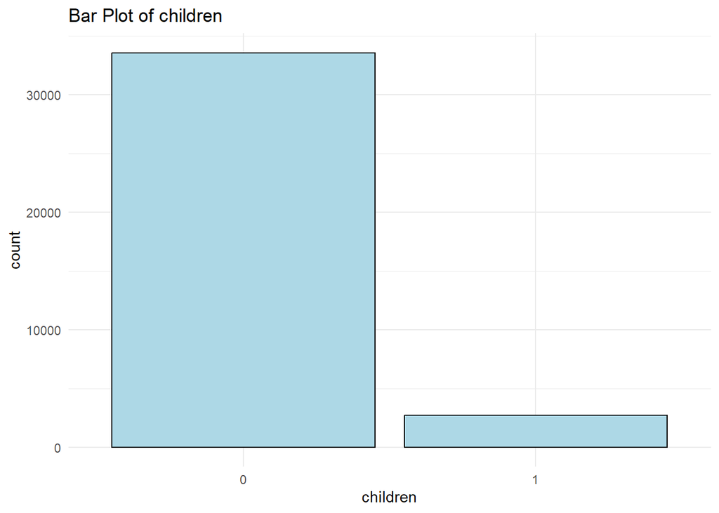

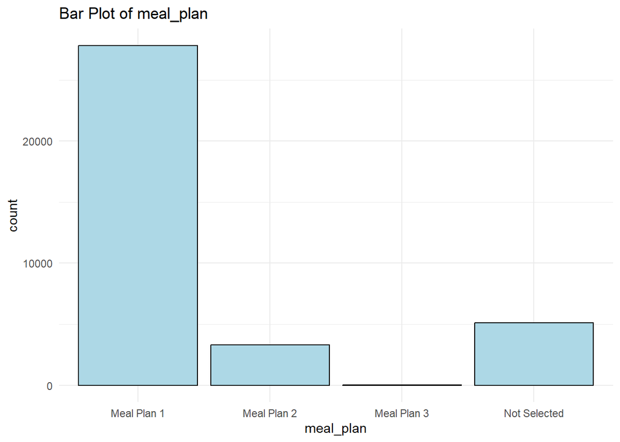

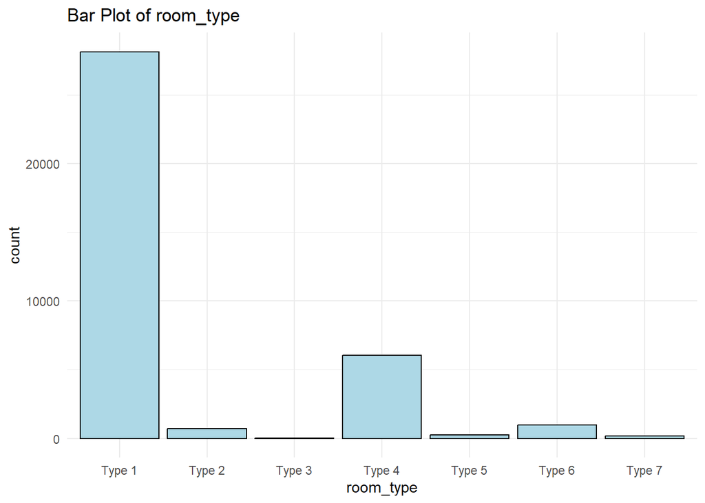

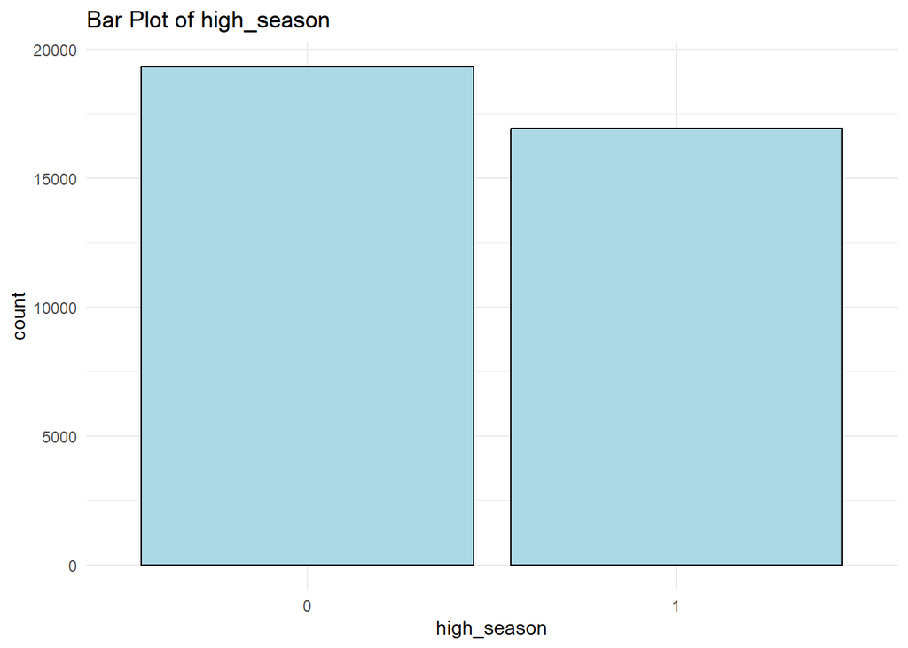

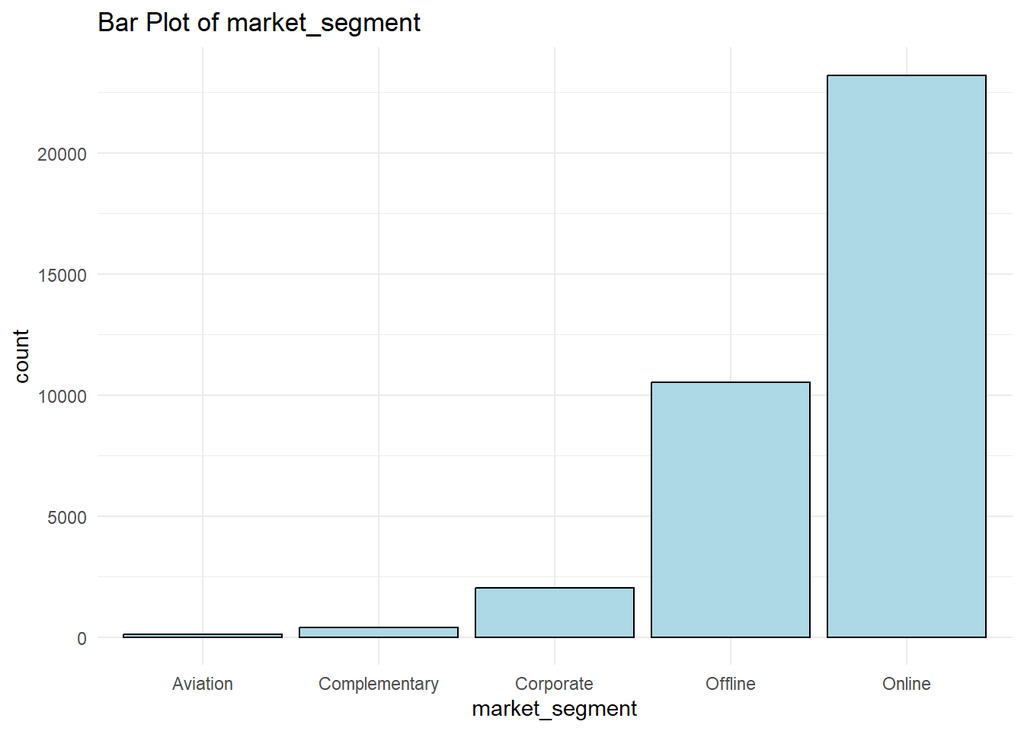

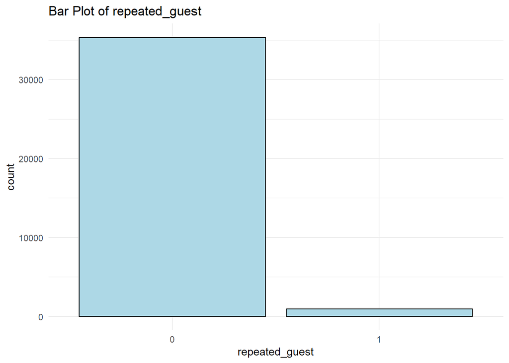

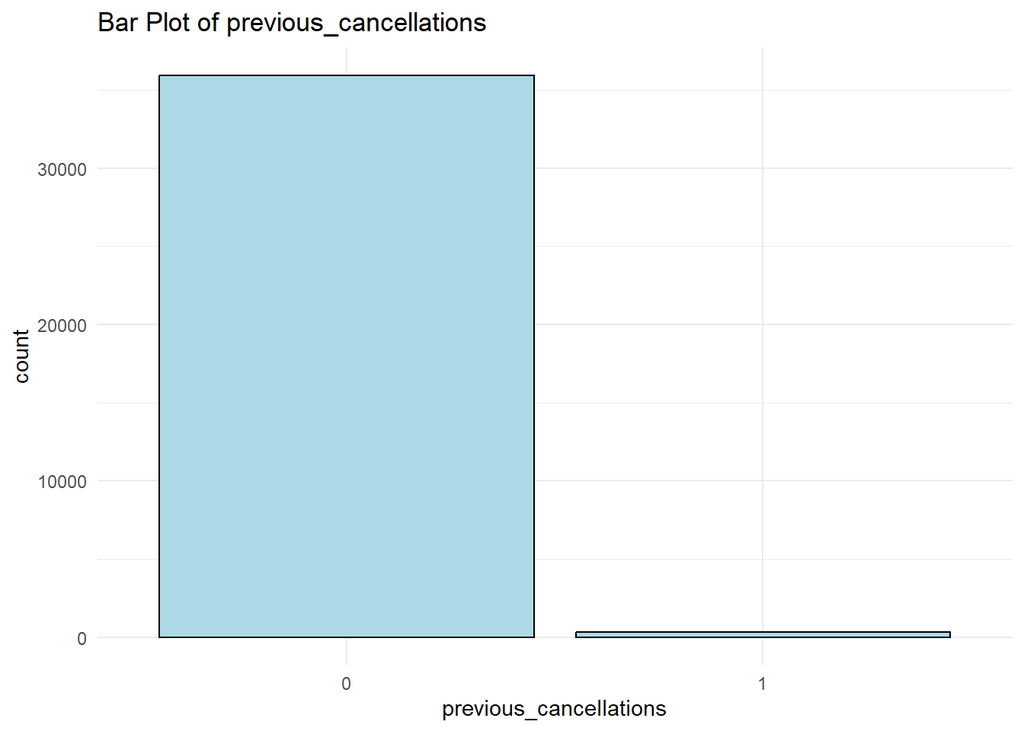

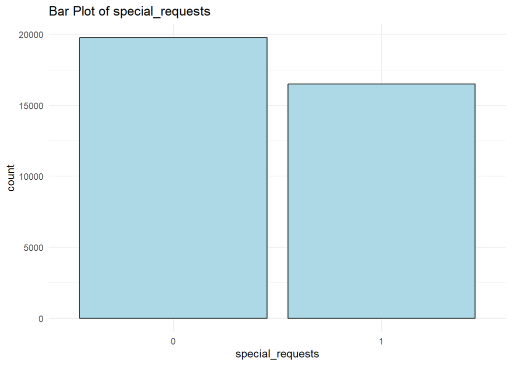

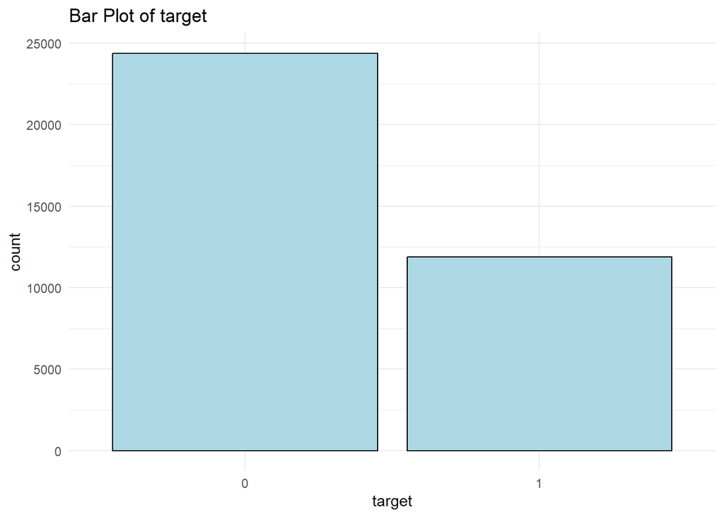

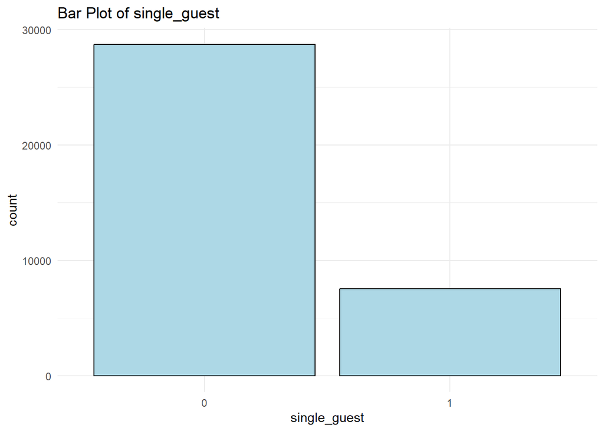

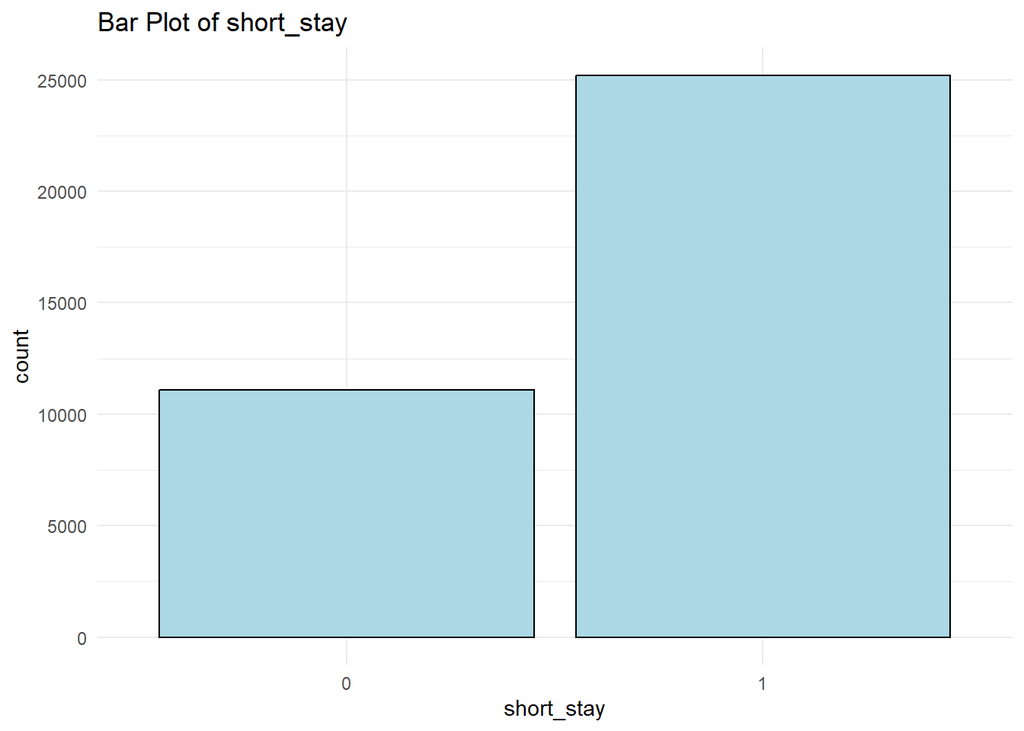

```r
# Gráficos de barras para las variables categóricas
for (i in cat_vars) {
  print(ggplot(df, aes(x = !!sym(i))) +
          geom_bar(fill = "lightblue", color = "black") +
          ggtitle(paste("Bar Plot of", i)) +
          theme_minimal())
}
```

### 5.2. ANÁLISIS BIVARIADO

Se realizará un análisis exhaustivo para identificar qué variables influyen significativamente en la variable objetivo (target), que indica si una reserva será cancelada o se hará efectiva, con el fin de mejorar la precisión del modelo predictivo.

Se evaluarán variables categóricas y numéricas para identificar las relaciones más significativas entre el comportamiento del cliente y las reservas. Se plantean las siguientes hipótesis a verificar:

- La anticipación de la reserva,
- Historial de cancelaciones,
- Número de solicitudes especiales,
- Duración de la estadía,
- Segmento de mercado
- Si el cliente es recurrente o nuevo.

#### 5.2.1. ANÁLISIS DE CORRELACIÓN (VARIABLES NUMÉRICAS)

```r
df_numeric <- df[, sapply(df, is.numeric)]
```

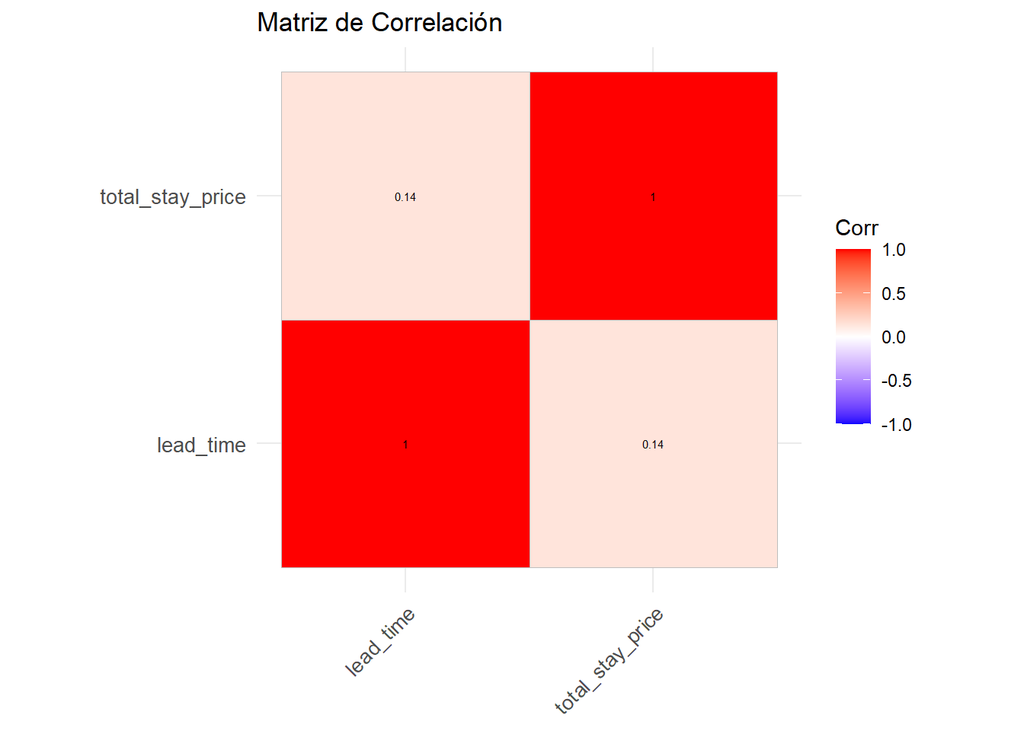

```r
# Crear la matriz de correlación
cor_matrix <- cor(df_numeric, use = "complete.obs")

# Generar la matriz de correlación con anotaciones
ggcorrplot(cor_matrix, lab = TRUE, # Mostrar los coeficientes de correlación
           lab_size = 2, # Tamaño del texto
           tl.cex = 10, # Tamaño de las etiquetas
           colors = c("blue", "white", "red"), # Escala de colores
           title = "Matriz de Correlación",
           ggtheme = theme_minimal())
```

#### 5.2.2. ANALISIS CON GTSUMMARY

```r
table1 <- df|>
  tbl_summary()
table1
```

| **Characteristic** | **N = 36,275**<sup>1</sup> |
| --- | --- |
| children |  |
| 0 | 33,577 (93%) |
| 1 | 2,698 (7.4%) |
| meal_plan |  |
| Meal Plan 1 | 27,835 (77%) |
| Meal Plan 2 | 3,305 (9.1%) |
| Meal Plan 3 | 5 (<0.1%) |
| Not Selected | 5,130 (14%) |
| room_type |  |
| Type 1 | 28,130 (78%) |
| Type 2 | 692 (1.9%) |
| Type 3 | 7 (<0.1%) |
| Type 4 | 6,057 (17%) |
| Type 5 | 265 (0.7%) |
| Type 6 | 966 (2.7%) |
| Type 7 | 158 (0.4%) |
| lead_time | 0.26 (0.08, 0.82) |
| high_season |  |
| 0 | 19,331 (53%) |
| 1 | 16,944 (47%) |
| market_segment |  |
| Aviation | 125 (0.3%) |
| Complementary | 391 (1.1%) |
| Corporate | 2,017 (5.6%) |
| Offline | 10,528 (29%) |
| Online | 23,214 (64%) |
| repeated_guest |  |
| 0 | 35,345 (97%) |
| 1 | 930 (2.6%) |
| previous_cancellations |  |
| 0 | 35,937 (99%) |
| 1 | 338 (0.9%) |
| special_requests |  |
| 0 | 19,777 (55%) |
| 1 | 16,498 (45%) |
| target |  |
| 0 | 24,390 (67%) |
| 1 | 11,885 (33%) |
| single_guest |  |
| 0 | 28,723 (79%) |
| 1 | 7,552 (21%) |
| short_stay |  |
| 0 | 11,069 (31%) |
| 1 | 25,206 (69%) |
| total_stay_price | 0.35 (0.12, 0.76) |

<sup>1</sup> n (%); Median (Q1, Q3)

```r
table2 <- tbl_summary(df, by = target)|>
add_n() |> # add column with total number of non-missing observations
add_p() |>  # test for a difference between groups
modify_header(label = "**Variable**") |> # update the column header
bold_labels()
```

[output not shown]

```r
table2
```

| **Variable** | **N** | **0** N = 24,390<sup>1</sup> | **1** N = 11,885<sup>1</sup> | **p-value**<sup>2</sup> |
| --- | --- | --- | --- | --- |
| children | 36,275 |  |  | <0.001 |
| 0 |  | 22,695 (93%) | 10,882 (92%) |  |
| 1 |  | 1,695 (6.9%) | 1,003 (8.4%) |  |
| meal_plan | 36,275 |  |  |  |
| Meal Plan 1 |  | 19,156 (79%) | 8,679 (73%) |  |
| Meal Plan 2 |  | 1,799 (7.4%) | 1,506 (13%) |  |
| Meal Plan 3 |  | 4 (<0.1%) | 1 (<0.1%) |  |
| Not Selected |  | 3,431 (14%) | 1,699 (14%) |  |
| room_type | 36,275 |  |  |  |
| Type 1 |  | 19,058 (78%) | 9,072 (76%) |  |
| Type 2 |  | 464 (1.9%) | 228 (1.9%) |  |
| Type 3 |  | 5 (<0.1%) | 2 (<0.1%) |  |
| Type 4 |  | 3,988 (16%) | 2,069 (17%) |  |
| Type 5 |  | 193 (0.8%) | 72 (0.6%) |  |
| Type 6 |  | 560 (2.3%) | 406 (3.4%) |  |
| Type 7 |  | 122 (0.5%) | 36 (0.3%) |  |
| lead_time | 36,275 | 0.16 (0.06, 0.51) | 0.79 (0.25, 0.99) | <0.001 |
| high_season | 36,275 |  |  | <0.001 |
| 0 |  | 13,643 (56%) | 5,688 (48%) |  |
| 1 |  | 10,747 (44%) | 6,197 (52%) |  |
| market_segment | 36,275 |  |  | <0.001 |
| Aviation |  | 88 (0.4%) | 37 (0.3%) |  |
| Complementary |  | 391 (1.6%) | 0 (0%) |  |
| Corporate |  | 1,797 (7.4%) | 220 (1.9%) |  |
| Offline |  | 7,375 (30%) | 3,153 (27%) |  |
| Online |  | 14,739 (60%) | 8,475 (71%) |  |
| repeated_guest | 36,275 |  |  | <0.001 |
| 0 |  | 23,476 (96%) | 11,869 (100%) |  |
| 1 |  | 914 (3.7%) | 16 (0.1%) |  |
| previous_cancellations | 36,275 |  |  | <0.001 |
| 0 |  | 24,068 (99%) | 11,869 (100%) |  |
| 1 |  | 322 (1.3%) | 16 (0.1%) |  |
| special_requests | 36,275 |  |  | <0.001 |
| 0 |  | 11,232 (46%) | 8,545 (72%) |  |
| 1 |  | 13,158 (54%) | 3,340 (28%) |  |
| single_guest | 36,275 |  |  | <0.001 |
| 0 |  | 18,647 (76%) | 10,076 (85%) |  |
| 1 |  | 5,743 (24%) | 1,809 (15%) |  |
| short_stay | 36,275 |  |  | <0.001 |
| 0 |  | 7,137 (29%) | 3,932 (33%) |  |
| 1 |  | 17,253 (71%) | 7,953 (67%) |  |
| total_stay_price | 36,275 | 0.30 (0.09, 0.71) | 0.45 (0.20, 0.85) | <0.001 |

<sup>1</sup> n (%); Median (Q1, Q3)  
<sup>2</sup> Pearson’s Chi-squared test; Wilcoxon rank sum test

**Interpretación:**

**Nota**: Los cálculos estadísticos para las variables *meal_plan* y *room_type* no pudieron completarse debido a limitaciones en el espacio de trabajo del algoritmo que implementa la prueba exacta de Fisher (Fisher’s Exact Test). Esta prueba es particularmente exigente en términos de memoria y recursos computacionales cuando se manejan tablas grandes o complejas. Dado que no fue posible obtener los resultados de significancia estadística para estas variables y no se logró ajustar adecuadamente los recursos requeridos, se ha decidido no incluirlas en el análisis predictivo para evitar posibles sesgos o interpretaciones incorrectas.

Del mismo modo, se elimina la columna **“*market_segment”*** debido a su distribución desbalanceada, donde segmentos minoritarios como *Aviation* y *Complementary* tienen muy pocos datos. Esto afecta la relevancia predictiva de la variable y podría generar sesgos en el modelo. Los segmentos predominantes (*Online* y *Offline*) ya capturan la mayor parte de la variabilidad.

```r
# Eliminamos las columnas 'meal_plan' y 'room_type'
df <- df %>% select(-meal_plan, -room_type, -market_segment)
head(df)
```

```
##   children  lead_time high_season repeated_guest previous_cancellations
## 1        0 0.99377710           1              0                      0
## 2        0 0.05053335           0              0                      0
## 3        0 0.04396061           0              0                      0
## 4        0 0.99002849           0              0                      0
## 5        0 0.20404440           0              0                      0
## 6        0 0.99992762           1              0                      0
##   special_requests target single_guest short_stay total_stay_price
## 1                0      0            0          1        0.1542009
## 2                1      0            0          0        0.9603345
## 3                0      1            1          1        0.1280034
## 4                0      1            0          1        0.1638590
## 5                0      1            0          1        0.1432314
## 6                1      1            0          1        0.2321190
```

## 6. PREDICTION

### 6.1. MODELO ESTADISTICO: REGRESION LOGISTICA

#### 6.1.1. SEPARACION DE LA DATA

```r
# Separación de la data en entrenamiento, validación y prueba
library(rsample)

set.seed(123)  # Fijar semilla para reproducibilidad

# Paso 1: División inicial (70% entrenamiento, 30% test+validación)
data_split <- initial_split(df, prop = 0.7, strata = target)
train_data <- training(data_split)
test_validation_data <- testing(data_split)

# Paso 2: División del conjunto test+validación en 50% test y 50% validación
validation_split <- initial_split(test_validation_data, prop = 0.5, strata = target)
validation_data <- training(validation_split)
test_data <- testing(validation_split)

# Revisión de las primeras observaciones de cada conjunto
head(train_data)
```

```
##   children  lead_time high_season repeated_guest previous_cancellations
## 1        0 0.05053335           0              0                      0
## 2        0 0.47960600           0              0                      0
## 3        0 0.78711829           0              0                      0
## 4        0 0.04244945           1              0                      0
## 5        0 0.19817095           1              0                      0
## 6        0 0.04244945           1              0                      0
##   special_requests target single_guest short_stay total_stay_price
## 1                1      0            0          0       0.96033448
## 2                1      0            0          0       0.82973826
## 3                1      0            0          0       0.74657801
## 4                0      0            1          1       0.03588992
## 5                1      0            0          1       0.14323137
## 6                0      0            1          1       0.04179574
```

```r
head(validation_data)
```

```
##   children  lead_time high_season repeated_guest previous_cancellations
## 1        0 0.13319040           1              0                      0
## 2        0 0.18131789           1              0                      0
## 3        0 0.13746812           0              0                      0
## 4        0 0.26266366           0              0                      0
## 5        0 0.05415914           0              0                      0
## 6        0 0.06655892           1              0                      0
##   special_requests target single_guest short_stay total_stay_price
## 1                1      0            0          0       0.84499603
## 2                1      0            0          0       0.99405825
## 3                1      0            1          1       0.82719251
## 4                1      0            0          0       0.51439723
## 5                1      0            1          0       0.93994178
## 6                1      0            0          1       0.03792818
```

```r
head(test_data)
```

```
##   children  lead_time high_season repeated_guest previous_cancellations
## 1        0 0.99377710           1              0                      0
## 2        0 0.06432319           1              0                      0
## 3        0 0.62324196           1              0                      0
## 4        0 0.38136077           1              0                      0
## 5        0 0.59716176           0              0                      0
## 6        0 0.63178711           0              0                      0
##   special_requests target single_guest short_stay total_stay_price
## 1                0      0            0          1       0.15420093
## 2                0      0            0          1       0.02991593
## 3                0      1            0          0       0.31800005
## 4                0      0            0          1       0.11417870
## 5                1      0            0          1       0.68129365
## 6                1      0            0          0       0.96577374
```

#### 6.1.2. BALANCEO DE LOS DATOS DE ENTRENAMIENTO

```r
table(train_data$target)
```

```
##
##     0     1
## 17073  8319
```

```r
table(validation_data$target)
```

```
##
##    0    1
## 3658 1783
```

#### 6.1.3. ENTRENAMIENTO DE LOS DATOS

```r
#Entrenamiento y selección de los hiperparámetros del modelo de regresión logística
glm_model <- glm(target ~ ., data = train_data, family = binomial())
#Resumen del modelo entrenado
summary(glm_model)
```

```
##
## Call:
## glm(formula = target ~ ., family = binomial(), data = train_data)
##
## Coefficients:
##                          Estimate Std. Error z value Pr(>|z|)
## (Intercept)              -2.42794    0.06524 -37.214  < 2e-16 ***
## children1                 0.29155    0.05890   4.950 7.42e-07 ***
## lead_time                 2.45985    0.04341  56.663  < 2e-16 ***
## high_season1             -0.01153    0.03178  -0.363    0.717
## repeated_guest1         -14.24513  109.19171  -0.130    0.896
## previous_cancellations1  12.75453  109.19218   0.117    0.907
## special_requests1        -1.37701    0.03394 -40.569  < 2e-16 ***
## single_guest1            -0.46374    0.04325 -10.723  < 2e-16 ***
## short_stay1               0.72260    0.04702  15.369  < 2e-16 ***
## total_stay_price          1.54476    0.06662  23.187  < 2e-16 ***
## ---
## Signif. codes:  0 '***' 0.001 '**' 0.01 '*' 0.05 '.' 0.1 ' ' 1
##
## (Dispersion parameter for binomial family taken to be 1)
##
##     Null deviance: 32120  on 25391  degrees of freedom
## Residual deviance: 25172  on 25382  degrees of freedom
## AIC: 25192
##
## Number of Fisher Scoring iterations: 15
```

```r
#Transformamos los coeficientes en odds ratio:
exp(cbind(OR = coef(glm_model), confint(glm_model)))
```

```
##                                   OR        2.5 %       97.5 %
## (Intercept)             8.821859e-02 7.759978e-02 1.002154e-01
## children1               1.338504e+00 1.192242e+00 1.501920e+00
## lead_time               1.170301e+01 1.075097e+01 1.274544e+01
## high_season1            9.885341e-01 9.287915e-01 1.052035e+00
## repeated_guest1         6.507546e-07 1.272609e-31 3.141989e-36
## previous_cancellations1 3.461156e+05 8.583185e+01           NA
## special_requests1       2.523315e-01 2.360481e-01 2.696414e-01
## single_guest1           6.289274e-01 5.776920e-01 6.844200e-01
## short_stay1             2.059787e+00 1.878681e+00 2.258906e+00
## total_stay_price        4.686865e+00 4.113820e+00 5.341585e+00
```

Interpretación de Odds Ratio:

| Variable | OR | 2.5 % | 97.5 % | Interpretación |
| --- | --- | --- | --- | --- |

| **(Intercept)** | 0.0882 | 0.0776 | 0.1002 | El intercepto no tiene una interpretación directa, pero su valor implica que cuando todas las variables son cero, la odds de que ocurra el evento es baja. |
| --- | --- | --- | --- | --- |

| **children1** | 1.3385 | 1.1922 | 1.5019 | La presencia de un niño aumenta la probabilidad de que ocurra el evento (clase 1) en un 33.85% (1.3385 - 1) comparado con cuando no hay niños. |
| --- | --- | --- | --- | --- |

| **lead_time** | 11.7030 | 10.7509 | 12.7444 | Por cada aumento de una unidad en el tiempo de anticipación (lead time), la probabilidad de que ocurra el evento aumenta en un 1070.30%. |
| --- | --- | --- | --- | --- |

| **high_season1** | 0.9885 | 0.9288 | 1.0520 | Estar en alta temporada tiene un efecto ligeramente negativo (no significativo) en la probabilidad de que ocurra el evento. |
| --- | --- | --- | --- | --- |

| **repeated_guest1** | 0.00000065 | 1.2726e-31 | 3.1419e-36 | La probabilidad de que un huésped repetido ocurra es extremadamente baja, indicando que este grupo es poco probable que contribuya al evento. |
| --- | --- | --- | --- | --- |

| **previous_cancellations1** | 346115.6 | 85.83185 | NA | Cada cancelación previa aumenta significativamente la probabilidad del evento; un aumento en este factor lleva a una enorme probabilidad del evento. |
| --- | --- | --- | --- | --- |

| **special_requests1** | 0.2523 | 0.2360 | 0.2696 | Hacer solicitudes especiales reduce la probabilidad del evento en un 74.77% (1 - 0.2523). |
| --- | --- | --- | --- | --- |

| **single_guest1** | 0.6289 | 0.5777 | 0.6844 | Ser un huésped soltero reduce la probabilidad de que ocurra el evento en un 37.11% (1 - 0.6289). |
| --- | --- | --- | --- | --- |

| **short_stay1** | 2.0598 | 1.8787 | 2.2589 | Una estancia corta aumenta la probabilidad del evento en un 105.98% (2.0598 - 1) comparado con estancias más largas. |
| --- | --- | --- | --- | --- |

| **total_stay_price** | 4.6869 | 4.1138 | 5.3416 | Por cada unidad adicional de precio total de estancia, la probabilidad de que ocurra el evento aumenta en un 368.69% (4.6869 - 1). |
| --- | --- | --- | --- | --- |

#### 6.1.4. PREDICCION EN DATOS DE VALIDACION

```r
# Realizamos la predicción en los datos de validación
validation_glm <- predict(glm_model, newdata = validation_data, type="response")
# Convertimos las probabilidades en clases binarias (0 o 1) usando un umbral de 0.5
prediction_val <- ifelse(validation_glm > 0.5, 1, 0)

# Asegurarse de que ambas variables sean factores y tengan los mismos niveles
prediction_val <- factor(prediction_val, levels = c(0, 1))
validation_data$target <- factor(validation_data$target, levels = c(0, 1))

# Evaluar el modelo
confusionMatrix(prediction_val, validation_data$target)
```

```
## Confusion Matrix and Statistics
##
##           Reference
## Prediction    0    1
##          0 3215  851
##          1  443  932
##
##                Accuracy : 0.7622
##                  95% CI : (0.7506, 0.7734)
##     No Information Rate : 0.6723
##     P-Value [Acc > NIR] : < 2.2e-16
##
##                   Kappa : 0.4266
##
##  Mcnemar's Test P-Value : < 2.2e-16
##
##             Sensitivity : 0.8789
##             Specificity : 0.5227
##          Pos Pred Value : 0.7907
##          Neg Pred Value : 0.6778
##              Prevalence : 0.6723
##          Detection Rate : 0.5909
##    Detection Prevalence : 0.7473
##       Balanced Accuracy : 0.7008
##
##        'Positive' Class : 0
##
```

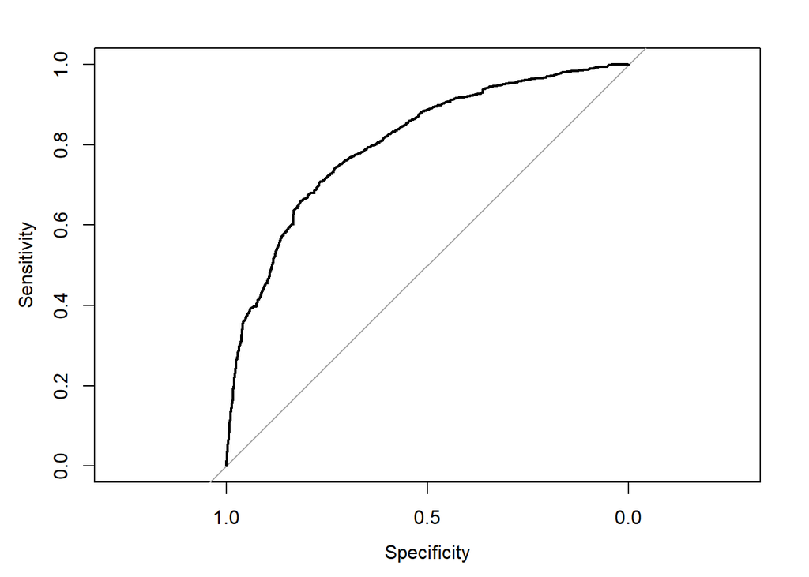

```r
roc_curve <- roc(validation_data$target, validation_glm)
plot(roc_curve)
```

```r
auc_value <- auc(roc_curve)
print(auc_value)
```

```
## Area under the curve: 0.8048
```

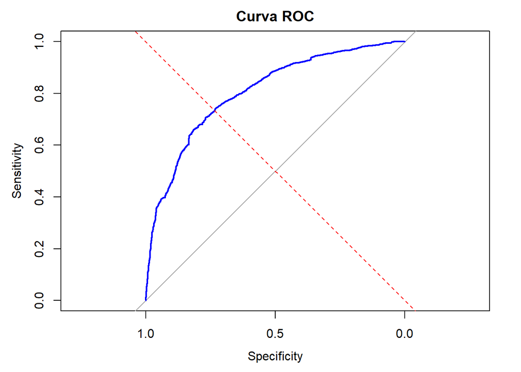

```r
roc_curve <- roc(validation_data$target, validation_glm)
plot(roc_curve, col = "blue", main = "Curva ROC")
abline(a = 0, b = 1, lty = 2, col = "red")  # Línea de referencia
```

#### 6.1.5. EVALUACION DEL MODELO CON LOS DATOS DE PRUEBA

```r
# Realizamos la predicción en los datos de prueba
y_pred_class <-  predict(glm_model,test_data, type="response")

# Convertimos las probabilidades en clases binarias (0 o 1) usando un umbral de 0.5
prediction_test <- ifelse(y_pred_class > 0.5, 1, 0)

# Asegurarse de que ambas variables sean factores y tengan los mismos niveles
prediction_test <- factor(prediction_test, levels = c(0, 1))
test_data$target <- factor(test_data$target, levels = c(0, 1))

# Evaluar el modelo
confusionMatrix(prediction_test, test_data$target)
```

```
## Confusion Matrix and Statistics
##
##           Reference
## Prediction    0    1
##          0 3205  916
##          1  454  867
##
##                Accuracy : 0.7483
##                  95% CI : (0.7365, 0.7597)
##     No Information Rate : 0.6724
##     P-Value [Acc > NIR] : < 2.2e-16
##
##                   Kappa : 0.388
##
##  Mcnemar's Test P-Value : < 2.2e-16
##
##             Sensitivity : 0.8759
##             Specificity : 0.4863
##          Pos Pred Value : 0.7777
##          Neg Pred Value : 0.6563
##              Prevalence : 0.6724
##          Detection Rate : 0.5889
##    Detection Prevalence : 0.7573
##       Balanced Accuracy : 0.6811
##
##        'Positive' Class : 0
##
```

### 6.2. MODELOS NO ESTADISTICOS

#### 6.2.1. PREPARACION DE LA DATA

```r
#Transformamos las variables del tipo factor en dummy y estandarizar las variables numéricas

# Creamos  la receta para transformar las variables
recipe_trans <- recipe(target ~ ., data = df) %>%
  step_normalize(all_numeric()) %>%   # Estandarizar (normalizar) las variables numéricas
  step_dummy(all_nominal(), -all_outcomes())# Convertimos variables categóricas a dummies

# Preparamos la receta
recipe_prep <- prep(recipe_trans)

# Aplicamos la receta a los datos para transformarlos
df_transformed <- bake(recipe_prep, new_data = df)

# Ver las primeras filas del dataframe transformado
head(df_transformed)
```

```
## # A tibble: 6 × 10
##   lead_time total_stay_price target children_X1 high_season_X1 repeated_guest_X1
##       <dbl>            <dbl> <fct>        <dbl>          <dbl>             <dbl>
## 1     1.56            -0.826 0                0              1                 0
## 2    -1.00             1.52  0                0              0                 0
## 3    -1.02            -0.902 1                0              0                 0
## 4     1.55            -0.797 1                0              0                 0
## 5    -0.588           -0.858 1                0              0                 0
## 6     1.57            -0.598 1                0              1                 0
## # ℹ 4 more variables: previous_cancellations_X1 <dbl>,
## #   special_requests_X1 <dbl>, single_guest_X1 <dbl>, short_stay_X1 <dbl>
```

```r
str(df_transformed)
```

```
## tibble [36,275 × 10] (S3: tbl_df/tbl/data.frame)
##  $ lead_time                : num [1:36275] 1.558 -1.005 -1.023 1.548 -0.588 ...
##  $ total_stay_price         : num [1:36275] -0.826 1.525 -0.902 -0.797 -0.858 ...
##  $ target                   : Factor w/ 2 levels "0","1": 1 1 2 2 2 2 1 1 1 1 ...
##  $ children_X1              : num [1:36275] 0 0 0 0 0 0 0 0 0 0 ...
##  $ high_season_X1           : num [1:36275] 1 0 0 0 0 1 1 0 0 1 ...
##  $ repeated_guest_X1        : num [1:36275] 0 0 0 0 0 0 0 0 0 0 ...
##  $ previous_cancellations_X1: num [1:36275] 0 0 0 0 0 0 0 0 0 0 ...
##  $ special_requests_X1      : num [1:36275] 0 1 0 0 0 1 1 1 1 1 ...
##  $ single_guest_X1          : num [1:36275] 0 0 1 0 0 0 0 0 0 0 ...
##  $ short_stay_X1            : num [1:36275] 1 0 1 1 1 1 0 0 0 0 ...
```

```r
#Guardar la receta o transformador de datos
saveRDS(recipe_prep, "transformador_receta.rds")

#Cargar la receta guardada o transformador de datos
loaded_recipe <- readRDS("transformador_receta.rds")
```

```r
#Aplicar la receta en nuevos datos, en este caso lo estamos aplicando a la misma data para compropbar que me devuelve los mismos valores. Se puede aplicar a nueva data que tenga las mismas columnas del df. Posteriormente se puede aplicar al predict.
nuevos_datos <- bake(loaded_recipe, new_data = df)
head(nuevos_datos)
```

```
## # A tibble: 6 × 10
##   lead_time total_stay_price target children_X1 high_season_X1 repeated_guest_X1
##       <dbl>            <dbl> <fct>        <dbl>          <dbl>             <dbl>
## 1     1.56            -0.826 0                0              1                 0
## 2    -1.00             1.52  0                0              0                 0
## 3    -1.02            -0.902 1                0              0                 0
## 4     1.55            -0.797 1                0              0                 0
## 5    -0.588           -0.858 1                0              0                 0
## 6     1.57            -0.598 1                0              1                 0
## # ℹ 4 more variables: previous_cancellations_X1 <dbl>,
## #   special_requests_X1 <dbl>, single_guest_X1 <dbl>, short_stay_X1 <dbl>
```

#### 6.2.2. SEPARACION DE LA DATA

```r
#Separación de la data de entrenamiento y prueba
set.seed(123)  # Fijar semilla para reproducibilidad
data_split <- initial_split(df_transformed, prop = 0.7, strata = target)

train_data <- training(data_split)
test_validation_data <- testing(data_split)

# Separación adicional del conjunto de test+validación (50% test, 50% validación)
validation_split <- initial_split(test_validation_data, prop = 0.5, strata = target)

# Conjuntos de validación y test final
validation_data <- training(validation_split)
test_data <- testing(validation_split)

# Revisar los primeros datos de cada conjunto
head(train_data)
```

```
## # A tibble: 6 × 10
##   lead_time total_stay_price target children_X1 high_season_X1 repeated_guest_X1
##       <dbl>            <dbl> <fct>        <dbl>          <dbl>             <dbl>
## 1    -1.00             1.52  0                0              0                 0
## 2     0.161            1.14  0                0              0                 0
## 3     0.997            0.902 0                0              0                 0
## 4    -1.03            -1.17  0                0              1                 0
## 5    -0.604           -0.858 0                0              1                 0
## 6    -1.03            -1.15  0                0              1                 0
## # ℹ 4 more variables: previous_cancellations_X1 <dbl>,
## #   special_requests_X1 <dbl>, single_guest_X1 <dbl>, short_stay_X1 <dbl>
```

```r
head(validation_data)
```

```
## # A tibble: 6 × 10
##   lead_time total_stay_price target children_X1 high_season_X1 repeated_guest_X1
##       <dbl>            <dbl> <fct>        <dbl>          <dbl>             <dbl>
## 1    -0.780            1.19  0                0              1                 0
## 2    -0.649            1.62  0                0              1                 0
## 3    -0.768            1.14  0                0              0                 0
## 4    -0.428            0.225 0                0              0                 0
## 5    -0.995            1.47  0                0              0                 0
## 6    -0.961           -1.16  0                0              1                 0
## # ℹ 4 more variables: previous_cancellations_X1 <dbl>,
## #   special_requests_X1 <dbl>, single_guest_X1 <dbl>, short_stay_X1 <dbl>
```

```r
head(test_data)
```

```
## # A tibble: 6 × 10
##   lead_time total_stay_price target children_X1 high_season_X1 repeated_guest_X1
##       <dbl>            <dbl> <fct>        <dbl>          <dbl>             <dbl>
## 1     1.56            -0.826 0                0              1                 0
## 2    -0.967           -1.19  0                0              1                 0
## 3     0.551           -0.348 1                0              1                 0
## 4    -0.106           -0.942 0                0              1                 0
## 5     0.481            0.711 0                0              0                 0
## 6     0.575            1.54  0                0              0                 0
## # ℹ 4 more variables: previous_cancellations_X1 <dbl>,
## #   special_requests_X1 <dbl>, single_guest_X1 <dbl>, short_stay_X1 <dbl>
```

#### 6.2.3. BALANCEO DE LOS DATOS DE ENTRENAMIENTO

```r
#Verificamos las dimensiones para ver el balanceo de la data
dim(train_data)
```

```
## [1] 25392    10
```

```r
dim(validation_data)
```

```
## [1] 5441   10
```

```r
#Balanceo de los datos
recipe_bal <- recipe(target  ~ ., data = train_data) %>%
  step_smote(target)
```

```r
# Preparar la receta y aplicar a los datos
prep_bal <- prep(recipe_bal)
data_balanced <- bake(prep_bal, new_data = NULL)

# Verificar el balance de clases
table(data_balanced$target)
```

```
##
##     0     1
## 17073 17073
```

#### 6.2.4. ENTRENAMIENTO DE LOS DATOS

```r
# Cross Validation. Definimos el método de control de entrenamiento
control <- trainControl(method="cv", number=5)  # k-fold cross-validation
performance_metric <- "Accuracy"  # Definimos la métrica para medir el error
```

```r
#Aplicamos todos los modelos que se quieran:
# Modelo LDA
lda.Db <- train(target~., data=train_data, method="lda",
                metric=performance_metric, trControl=control,preProcess=NULL,
                prob.model = TRUE)


mlp.Db <- train(target~., data=train_data, method="mlp",
                metric=performance_metric, trControl=control,preProcess=NULL,
                prob.model = TRUE)

# Modelo SVM Support Vector Machines
svm.Db <- train(target~., data=train_data, method="svmRadial",
                metric=performance_metric, trControl=control,preProcess=NULL,
                prob.model = TRUE)

# Modelo Random Forest
rf.Db <- train(target~., data=train_data, method="rf",
               metric=performance_metric, trControl=control,preProcess=NULL,
               prob.model = TRUE)

# Modelo XGboost
#xgboost#eta control the learning rate
xg<- train(target~., data=train_data, method="xgbLinear",
           metric=performance_metric, trControl=control,preProcess=NULL)

# Modelo Classification and Regression Trees (CART)
cart.Db <- train(target~., data=train_data, method="rpart",
                 metric=performance_metric, trControl=control, preProcess=NULL)


# Modelo Gradient Boosting (gbm)
#shrinkage : learning rate
gbm1<- train(target~., data=train_data, method="gbm",
             metric=performance_metric, trControl=control,preProcess=NULL)
# Modelo de Red Neuronal (neural network)
net<- train(target~., data=train_data, method="nnet",
            metric=performance_metric, trControl=control,preProcess=NULL,
            prob.model = TRUE)
# Modelo k-NN
k_nn<- train(target~., data=train_data, method="kknn",
             metric=performance_metric, trControl=control,preProcess=NULL)
```

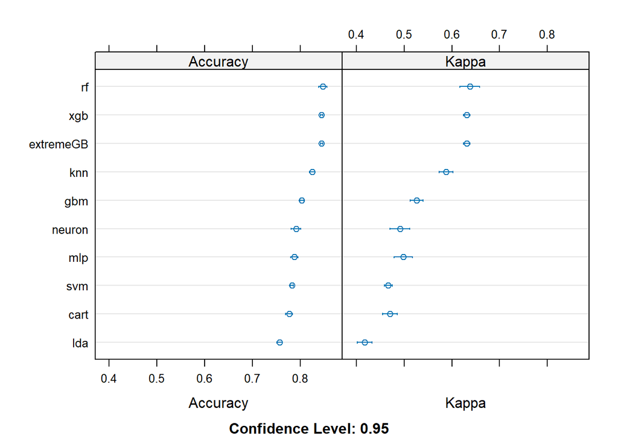

```r
#Resumen de los resultados
results.Db <- resamples(list(lda=lda.Db,mlp= mlp.Db,knn=k_nn ,
                             cart=cart.Db,extremeGB=xg,
                             gbm=gbm1,neuron = net, svm=svm.Db,
                             rf=rf.Db, xgb=xg))
df1 <- summary(results.Db)
dotplot(results.Db)
```

#### 6.2.5. PREDICCIONES EN LOS DATOS DE VALIDACION

```r
# Realizamos la predicción en los datos de validación
validation_predictions <- predict(rf.Db, newdata = validation_data, type="raw")

confusionMatrix(data = validation_predictions,
                reference = validation_data$target,
                mode="everything")
```

```
## Confusion Matrix and Statistics
##
##           Reference
## Prediction    0    1
##          0 3387  521
##          1  271 1262
##
##                Accuracy : 0.8544
##                  95% CI : (0.8448, 0.8637)
##     No Information Rate : 0.6723
##     P-Value [Acc > NIR] : < 2.2e-16
##
##                   Kappa : 0.6573
##
##  Mcnemar's Test P-Value : < 2.2e-16
##
##             Sensitivity : 0.9259
##             Specificity : 0.7078
##          Pos Pred Value : 0.8667
##          Neg Pred Value : 0.8232
##               Precision : 0.8667
##                  Recall : 0.9259
##                      F1 : 0.8953
##              Prevalence : 0.6723
##          Detection Rate : 0.6225
##    Detection Prevalence : 0.7183
##       Balanced Accuracy : 0.8169
##
##        'Positive' Class : 0
##
```

#### 6.2.6. EVALUACION DEL MODELO CON LOS DATOS DE PRUEBA

```r
# Realizamos la predicción en los datos de prueba
y_pred_class <-  predict(rf.Db,test_data, type="raw")
y_pred_prob <-  predict(rf.Db,test_data, type="prob")

confusionMatrix(data = y_pred_class,
                reference = test_data$target,
                mode="everything")
```

```
## Confusion Matrix and Statistics
##
##           Reference
## Prediction    0    1
##          0 3429  574
##          1  230 1209
##
##                Accuracy : 0.8523
##                  95% CI : (0.8426, 0.8616)
##     No Information Rate : 0.6724
##     P-Value [Acc > NIR] : < 2.2e-16
##
##                   Kappa : 0.6472
##
##  Mcnemar's Test P-Value : < 2.2e-16
##
##             Sensitivity : 0.9371
##             Specificity : 0.6781
##          Pos Pred Value : 0.8566
##          Neg Pred Value : 0.8402
##               Precision : 0.8566
##                  Recall : 0.9371
##                      F1 : 0.8951
##              Prevalence : 0.6724
##          Detection Rate : 0.6301
##    Detection Prevalence : 0.7356
##       Balanced Accuracy : 0.8076
##
##        'Positive' Class : 0
##
```

**Insights:**

Analizamos las métricas para ambas predicciones y se tiene que:

**1.** **Accuracy (Exactitud)**:

- **Validation Accuracy**: 0.8544 (85.44%)
- **Test Accuracy**: 0.8523 (85.23%)

Esto indica que en ambos conjuntos de datos, elmodelo clasificó correctamente alrededor del 85% de las instancias. La exactitud es bastante alta y similar en ambos casos, lo que sugiere que el modelo generaliza bien, es decir, no está sobreajustado a los datos de entrenamiento.

2. **Kappa**:

- **Validation Kappa**: 0.6573
- **Test Kappa**: 0.6472

El estadístico Kappa mide el acuerdo entre la predicción del modelo y las etiquetas reales, ajustando por el azar. Valores de Kappa entre 0.6 y 0.8 indican un acuerdo sustancial. En este caso, los valores están alrededor de 0.65, lo que significa que el rendimiento del modelo es sólido y mejor que el azar, pero aún hay margen para mejora.

3. **Sensitivity (Verdaderos positivos ‘0’)**:

- **Validation Sensitivity**: 0.9259 (92.59%)
- **Test Sensitivity**: 0.9371 (93.71%)

La sensibilidad mide qué tan bien el modelo identifica correctamente los verdaderos positivos. En ambos conjuntos de datos, la sensibilidad es alta, lo que significa que el modelo identifica correctamente la mayoría de los casos donde no se canceló la reserva.

4. **Specificity (Verdaderos negativos ‘1’)**:

- **Validation Specificity**: 0.7078 (70.78%)
- **Test Specificity**: 0.6781 (67.81%)

La especificidad mide qué tan bien el modelo identifica correctamente los verdaderos negativos. En este caso, la especificidad es algo más baja que la sensibilidad, lo que significa que el modelo tiene más dificultades para identificar correctamente los casos donde se canceló la reserva.

5. **Precision (Precisión)**:

- **Validation Precision**: 0.8667 (86.67%)
- **Test Precision**: 0.8566 (85.66%)

La precisión mide la proporción de verdaderos positivos entre todas las predicciones positivas . Una precisión alta indica que cuando el modelo predice que la reserva no se cancelará, lo hace de manera confiable.

6. **Balanced Accuracy (Exactitud balanceada)**:

- **Validation Balanced Accuracy**: 0.8169 (81.69%)
- **Test Balanced Accuracy**: 0.8076 (80.76%)

De acuerdo con los resultados el modelo de **Random Forest** ha mostrado un buen rendimiento en el conjunto de datos de prueba.

#### 6.2.7. CURVA ROC

Real vs Predicción

```r
# Obtener las probabilidades predichas
y_pred_prob <- predict(rf.Db, test_data, type = "prob")[, 2]

# Calcular la curva ROC
roc_curve <- roc(test_data$target, y_pred_prob)
#Area bajo la curva
auc_value <- auc(roc_curve)
print(auc_value)
```

```
## Area under the curve: 0.8976
```

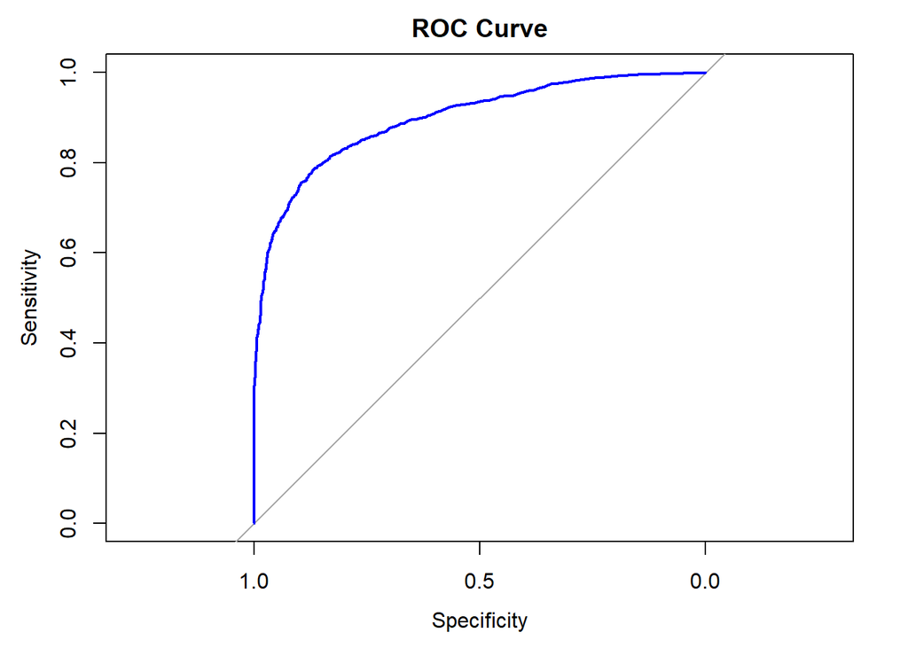

```r
# Graficar la curva ROC
plot(roc_curve, col = "blue", main = "ROC Curve")
```

### 6.4. PREDICCION EN DATOS NUEVOS

```r
new_data <- tibble(
  lead_time = c(14, 60, 3, 30, 90), # Tiempo en días entre la reserva y la llegada
  single_guest = c(1, 0, 1, 0, 0), # Número total de huéspedes
  short_stay = c(1, 0, 1, 0, 0), # Número total de noches de la estadía
  total_stay_price = c(300, 1000, 150, 750, 400), # Precio total de la estadía
  children = c(0, 1, 0, 1, 1), # Indicador si hay niños (1 = sí, 0 = no)
  high_season = c(1, 0, 1, 1, 0), # Indicador de temporada alta (1 = sí, 0 = no)
  repeated_guest = c(0, 1, 0, 0, 0), # Indicador si es un huésped repetido (1 = sí, 0 = no)
  previous_cancellations = c(0, 0, 0, 1, 1), # Número de cancelaciones anteriores
  special_requests = c(0, 1, 0, 1, 1) # Número de solicitudes especiales realizadas
)

# Transformar columnas a tipo factor
new_data <- new_data %>%
  mutate(
    children = as.factor(children),
    high_season = as.factor(high_season),
    repeated_guest = as.factor(repeated_guest),
    previous_cancellations = as.factor(previous_cancellations),
    single_guest = as.factor(single_guest),
    short_stay = as.factor(short_stay),
    special_requests = as.factor(special_requests)
  )
# Ver las primeras filas de los datos generados
print(new_data)
```

```
## # A tibble: 5 × 9
##   lead_time single_guest short_stay total_stay_price children high_season
##       <dbl> <fct>        <fct>                 <dbl> <fct>    <fct>
## 1        14 1            1                       300 0        1
## 2        60 0            0                      1000 1        0
## 3         3 1            1                       150 0        1
## 4        30 0            0                       750 1        1
## 5        90 0            0                       400 1        0
## # ℹ 3 more variables: repeated_guest <fct>, previous_cancellations <fct>,
## #   special_requests <fct>
```

```r
loaded_recipe <- readRDS("transformador_receta.rds")
```

```r
# Transformar los nuevos datos utilizando la receta
new_data_transformed <- bake(loaded_recipe, new_data = new_data)

# Realizar predicciones utilizando tu modelo entrenado
predictions <- predict(rf.Db, new_data_transformed)

# Ver las predicciones
print(predictions)
```

```
## [1] 1 1 1 1 1
## Levels: 0 1
```

Conclusión:

La predicción obtenida indica que, para los cinco nuevos datos introducidos, el modelo prevé que todas las reservas serán canceladas. Este resultado es notable, especialmente dado que el modelo ha mostrado un rendimiento robusto durante la fase de entrenamiento y validación, con una precisión general del 85% y una sensibilidad del 92.5%.